# Elsevier 2022 SDG mapping

# General to all SDGs

## Introduction

The United Nations Sustainable Development Goals (SDGs) challenge the global community to build a world where no one is left behind.

Since 2018, Elsevier has generated SDG search queries to help researchers and institutions track and demonstrate progress toward the SDG targets. In the past 3 years, these queries, along with the university’s own data and evidence supporting progress and contributions to the particular SDG outside of research-based metrics, are used for the THE Impact Rankings.

## Method

For 2022, this SDG uses the exact same search query and ML algorithm as the Elsevier 2021 SDG mapping, but with an addition of Covid related search terms.

[Full details of the 2021 methodology are available on Digital Commons Data.](https://elsevier.digitalcommonsdata.com/datasets/9sxdykm8s4/4)

# [SDG 3 - Ensure healthy lives and promote well-being for all at all ages](https://sdgs.un.org/goals/goal3)

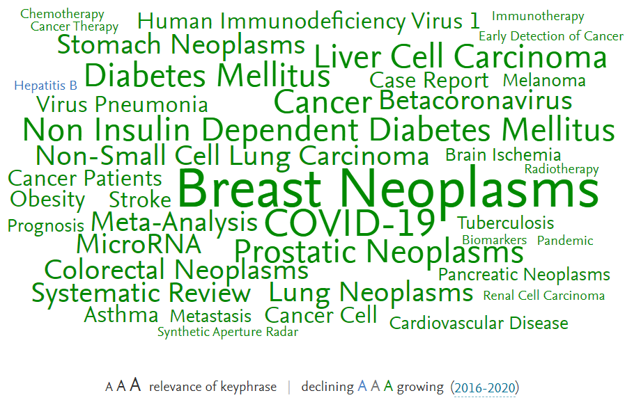

Explore this wordcloud plus the most active contributors on the [SciVal SDG site](https://scival.com/sdg)

## Query

Below is the full search query used for this SDG. We’ve broken it down by each query component. Use the + and – to concatenate the different bracket levels.

Note: the additional Covid search terms used for the 2022 SDG 3 can be seen in the 11th bracket level.

(

(

(

TITLE-ABS

(

"pedestrian safety"

)

OR AUTHKEY

(

"pedestrian safety"

)

OR TITLE-ABS

(

"crash safety"

)

OR AUTHKEY

(

"crash safety"

)

OR

(

TITLE-ABS("cycling accident") OR TITLE-ABS("cycling accidents")

)

OR

(

AUTHKEY("cycling accident") OR AUTHKEY("cycling accidents")

)

OR

(

TITLE-ABS("traffic collision") OR TITLE-ABS("traffic collisions")

)

OR

(

AUTHKEY("traffic collision") OR AUTHKEY("traffic collisions")

)

OR

(

TITLE-ABS("road collision") OR TITLE-ABS("road collisions")

)

OR

(

AUTHKEY("road collision") OR AUTHKEY("road collisions")

)

OR

(

TITLE-ABS("car collision") OR TITLE-ABS("car collisions")

)

OR

(

AUTHKEY("car collision") OR AUTHKEY("car collisions")

)

OR TITLE-ABS

(

"cycling safety"

)

OR AUTHKEY

(

"cycling safety"

)

OR

(

TITLE-ABS("nonfatal crash") OR TITLE-ABS("nonfatal crashes")

)

OR

(

AUTHKEY("nonfatal crash") OR AUTHKEY("nonfatal crashes")

)

OR

(

TITLE-ABS("bicycle collision") OR TITLE-ABS("bicycle collisions")

)

OR

(

AUTHKEY("bicycle collision") OR AUTHKEY("bicycle collisions")

)

OR

(

TITLE-ABS("pedestrian collision") OR TITLE-ABS("pedestrian collisions")

)

OR

(

AUTHKEY("pedestrian collision") OR AUTHKEY("pedestrian collisions")

)

OR

(

TITLE-ABS("vehicle death") OR TITLE-ABS("vehicle deaths")

)

OR

(

AUTHKEY("vehicle death") OR AUTHKEY("vehicle deaths")

)

OR

(

(TITLE-ABS("crash risk") OR TITLE-ABS("crash risks")) AND NOT (TITLE-ABS("stock price"))

)

OR

(

(AUTHKEY("crash risk") OR AUTHKEY("crash risks")) AND NOT (AUTHKEY("stock price"))

)

OR

(

TITLE-ABS("distracted driver") OR TITLE-ABS("distracted drivers")

)

OR

(

AUTHKEY("distracted driver") OR AUTHKEY("distracted drivers")

)

OR

(

TITLE-ABS("traffic fatality") OR TITLE-ABS("traffic fatalities")

)

OR

(

AUTHKEY("traffic fatality") OR AUTHKEY("traffic fatalities")

)

OR

(

TITLE-ABS("sobriety test") OR TITLE-ABS("sobriety tests")

)

OR

(

AUTHKEY("sobriety test") OR AUTHKEY("sobriety tests")

)

OR

(

TITLE-ABS("vehicular death") OR TITLE-ABS("vehicular deaths")

)

OR

(

AUTHKEY("vehicular death") OR AUTHKEY("vehicular deaths")

)

OR TITLE-ABS

(

"drugged driving"

)

OR AUTHKEY

(

"drugged driving"

)

OR

(

TITLE-ABS("driver fatality") OR TITLE-ABS("driver fatalities")

)

OR

(

AUTHKEY("driver fatality") OR AUTHKEY("driver fatalities")

)

OR

(

TITLE-ABS("risky driver") OR TITLE-ABS("risky drivers")

)

OR

(

AUTHKEY("risky driver") OR AUTHKEY("risky drivers")

)

OR TITLE-ABS

(

"motorcyclist safety"

)

OR AUTHKEY

(

"motorcyclist safety"

)

OR

(

TITLE-ABS("frontal crash") OR TITLE-ABS("frontal crashes")

)

OR

(

AUTHKEY("frontal crash") OR AUTHKEY("frontal crashes")

)

OR TITLE-ABS

(

"crash testing"

)

OR AUTHKEY

(

"crash testing"

)

OR

(

TITLE-ABS("crash fatality") OR TITLE-ABS("crash fatalities")

)

OR

(

AUTHKEY("crash fatality") OR AUTHKEY("crash fatalities")

)

OR TITLE-ABS

(

"safe driving"

)

OR AUTHKEY

(

"safe driving"

)

OR

(

TITLE-ABS("motorcycle injury") OR TITLE-ABS("motorcycle injuries")

)

OR

(

AUTHKEY("motorcycle injury") OR AUTHKEY("motorcycle injuries")

)

OR

(

TITLE-ABS("bicycling injury") OR TITLE-ABS("bicycling injuries")

)

OR

(

AUTHKEY("bicycling injury") OR AUTHKEY("bicycling injuries")

)

OR

(

TITLE-ABS("pedestrian injury") OR TITLE-ABS("pedestrian injuries")

)

OR

(

AUTHKEY("pedestrian injury") OR AUTHKEY("pedestrian injuries")

)

OR TITLE-ABS

(

"driving drowsiness"

)

OR AUTHKEY

(

"driving drowsiness"

)

OR TITLE-ABS

(

"driver fatigue"

)

OR AUTHKEY

(

"driver fatigue"

)

OR TITLE-ABS

(

"texting while driving"

)

OR AUTHKEY

(

"texting while driving"

)

OR

(

TITLE-ABS("vehicle accident") OR TITLE-ABS("vehicle accidents")

)

OR

(

AUTHKEY("vehicle accident") OR AUTHKEY("vehicle accidents")

)

OR

(

TITLE-ABS("fatal collision") OR TITLE-ABS("fatal collisions")

)

OR

(

AUTHKEY("fatal collision") OR AUTHKEY("fatal collisions")

)

OR

(

TITLE-ABS("aggressive driver") OR TITLE-ABS("aggressive drivers")

)

OR

(

AUTHKEY("aggressive driver") OR AUTHKEY("aggressive drivers")

)

OR TITLE-ABS

(

"driving impairment"

)

OR AUTHKEY

(

"driving impairment"

)

OR

(

TITLE-ABS("vehicle mortality") OR TITLE-ABS("vehicle mortalities")

)

OR

(

AUTHKEY("vehicle mortality") OR AUTHKEY("vehicle mortalities")

)

OR

(

TITLE-ABS("traffic accident") OR TITLE-ABS("traffic accidents")

)

OR

(

AUTHKEY("traffic accident") OR AUTHKEY("traffic accidents")

)

OR TITLE-ABS

(

"car security"

)

OR AUTHKEY

(

"car security"

)

OR TITLE-ABS

(

"passenger safety"

)

OR AUTHKEY

(

"passenger safety"

)

OR TITLE-ABS

(

"risky driving"

)

OR AUTHKEY

(

"risky driving"

)

OR TITLE-ABS

(

"sleepy driving"

)

OR AUTHKEY

(

"sleepy driving"

)

OR

(

TITLE-ABS("motorcycle accident") OR TITLE-ABS("motorcycle accidents")

)

OR

(

AUTHKEY("motorcycle accident") OR AUTHKEY("motorcycle accidents")

)

OR TITLE-ABS

(

"crashworthiness"

)

OR AUTHKEY

(

"crashworthiness"

)

OR

(

TITLE-ABS("bus accident") OR TITLE-ABS("bus accidents")

)

OR

(

AUTHKEY("bus accident") OR AUTHKEY("bus accidents")

)

OR

(

TITLE-ABS("motorcyclist fatality") OR TITLE-ABS("motorcyclist fatalities")

)

OR

(

AUTHKEY("motorcyclist fatality") OR AUTHKEY("motorcyclist fatalities")

)

OR TITLE-ABS

(

"drowsiness detection"

)

OR AUTHKEY

(

"drowsiness detection"

)

OR TITLE-ABS

(

"unsafe driving"

)

OR AUTHKEY

(

"unsafe driving"

)

OR

(

TITLE-ABS("cyclist fatality") OR TITLE-ABS("cyclist fatalities")

)

OR

(

AUTHKEY("cyclist fatality") OR AUTHKEY("cyclist fatalities")

)

OR

(

TITLE-ABS("vehicle collision") OR TITLE-ABS("vehicle collisions")

)

OR

(

AUTHKEY("vehicle collision") OR AUTHKEY("vehicle collisions")

)

OR TITLE-ABS

(

"driving under the influence"

)

OR AUTHKEY

(

"driving under the influence"

)

OR TITLE-ABS

(

"highway safety"

)

OR AUTHKEY

(

"highway safety"

)

OR

(

TITLE-ABS("traffic crash") OR TITLE-ABS("traffic crashes")

)

OR

(

AUTHKEY("traffic crash") OR AUTHKEY("traffic crashes")

)

OR

(

TITLE-ABS("road fatality") OR TITLE-ABS("road fatalities")

)

OR

(

AUTHKEY("road fatality") OR AUTHKEY("road fatalities")

)

OR

(

TITLE-ABS("car crash") OR TITLE-ABS("car crashes")

)

OR

(

AUTHKEY("car crash") OR AUTHKEY("car crashes")

)

OR

(

TITLE-ABS("motorcycle death") OR TITLE-ABS("motorcycle deaths")

)

OR

(

AUTHKEY("motorcycle death") OR AUTHKEY("motorcycle deaths")

)

OR TITLE-ABS

(

"road safety"

)

OR AUTHKEY

(

"road safety"

)

OR

(

TITLE-ABS("crash simulation") OR TITLE-ABS("crash simulations")

)

OR

(

AUTHKEY("crash simulation") OR AUTHKEY("crash simulations")

)

OR TITLE-ABS

(

"fatigue driving"

)

OR AUTHKEY

(

"fatigue driving"

)

OR TITLE-ABS

(

"driver alertness"

)

OR AUTHKEY

(

"driver alertness"

)

OR

(

TITLE-ABS("pedestrian accident") OR TITLE-ABS("pedestrian accidents")

)

OR

(

AUTHKEY("pedestrian accident") OR AUTHKEY("pedestrian accidents")

)

OR

(

TITLE-ABS("bicycle crash") OR TITLE-ABS("bicycle crashes")

)

OR

(

AUTHKEY("bicycle crash") OR AUTHKEY("bicycle crashes")

)

OR

(

TITLE-ABS("pedestrian crash") OR TITLE-ABS("pedestrian crashes")

)

OR

(

AUTHKEY("pedestrian crash") OR AUTHKEY("pedestrian crashes")

)

OR

(

TITLE-ABS("traffic injury") OR TITLE-ABS("traffic injuries")

)

OR

(

AUTHKEY("traffic injury") OR AUTHKEY("traffic injuries")

)

OR

(

TITLE-ABS("drunk driver") OR TITLE-ABS("drunk drivers")

)

OR

(

AUTHKEY("drunk driver") OR AUTHKEY("drunk drivers")

)

OR

(

TITLE-ABS("cyclist accident") OR TITLE-ABS("cyclist accidents")

)

OR

(

AUTHKEY("cyclist accident") OR AUTHKEY("cyclist accidents")

)

OR TITLE-ABS

(

"bicycling safety"

)

OR AUTHKEY

(

"bicycling safety"

)

OR

(

TITLE-ABS("driver distraction") OR TITLE-ABS("driver distractions")

)

OR

(

AUTHKEY("driver distraction") OR AUTHKEY("driver distractions")

)

OR

(

TITLE-ABS("driver injury") OR TITLE-ABS("driver injuries")

)

OR

(

AUTHKEY("driver injury") OR AUTHKEY("driver injuries")

)

OR TITLE-ABS

(

"reckless driving"

)

OR AUTHKEY

(

"reckless driving"

)

OR

(

TITLE-ABS("crash test") OR TITLE-ABS("crash tests")

)

OR

(

AUTHKEY("crash test") OR AUTHKEY("crash tests")

)

OR TITLE-ABS

(

"bus safety"

)

OR AUTHKEY

(

"bus safety"

)

OR

(

TITLE-ABS("traffic death") OR TITLE-ABS("traffic deaths")

)

OR

(

AUTHKEY("traffic death") OR AUTHKEY("traffic deaths")

)

OR

(

TITLE-ABS("road injury") OR TITLE-ABS("road injuries")

)

OR

(

AUTHKEY("road injury") OR AUTHKEY("road injuries")

)

OR

(

TITLE-ABS("impaired driver") OR TITLE-ABS("impaired drivers")

)

OR

(

AUTHKEY("impaired driver") OR AUTHKEY("impaired drivers")

)

OR

(

TITLE-ABS("crash injury") OR TITLE-ABS("crash injuries")

)

OR

(

AUTHKEY("crash injury") OR AUTHKEY("crash injuries")

)

OR

(

TITLE-ABS("motorcycle fatality") OR TITLE-ABS("motorcycle fatalities")

)

OR

(

AUTHKEY("motorcycle fatality") OR AUTHKEY("motorcycle fatalities")

)

OR TITLE-ABS

(

"motorcycle safety"

)

OR AUTHKEY

(

"motorcycle safety"

)

OR

(

TITLE-ABS("bicycle injury") OR TITLE-ABS("bicycle injuries")

)

OR

(

AUTHKEY("bicycle injury") OR AUTHKEY("bicycle injuries")

)

OR

(

TITLE-ABS("road accident") OR TITLE-ABS("road accidents")

)

OR

(

AUTHKEY("road accident") OR AUTHKEY("road accidents")

)

OR TITLE-ABS

(

"driving fatigue"

)

OR AUTHKEY

(

"driving fatigue"

)

OR TITLE-ABS

(

"driver safety"

)

OR AUTHKEY

(

"driver safety"

)

OR

(

TITLE-ABS("fatal crash") OR TITLE-ABS("fatal crashes")

)

OR

(

AUTHKEY("fatal crash") OR AUTHKEY("fatal crashes")

)

OR

(

TITLE-ABS("cyclist collision") OR TITLE-ABS("cyclist collisions")

)

OR

(

AUTHKEY("cyclist collision") OR AUTHKEY("cyclist collisions")

)

OR

(

TITLE-ABS("vehicular accident") OR TITLE-ABS("vehicular accidents")

)

OR

(

AUTHKEY("vehicular accident") OR AUTHKEY("vehicular accidents")

)

OR TITLE-ABS

(

"aggressive driving"

)

OR AUTHKEY

(

"aggressive driving"

)

OR

(

TITLE-ABS("driving distraction") OR TITLE-ABS("driving distractions")

)

OR

(

AUTHKEY("driving distraction") OR AUTHKEY("driving distractions")

)

OR

(

TITLE-ABS("driving fatality") OR TITLE-ABS("driving fatalities")

)

OR

(

AUTHKEY("driving fatality") OR AUTHKEY("driving fatalities")

)

OR TITLE-ABS

(

"crash performance"

)

OR AUTHKEY

(

"crash performance"

)

OR TITLE-ABS

(

"pedestrian protection"

)

OR AUTHKEY

(

"pedestrian protection"

)

OR

(

TITLE-ABS("cycling collision") OR TITLE-ABS("cycling collisions")

)

OR

(

AUTHKEY("cycling collision") OR AUTHKEY("cycling collisions")

)

OR TITLE-ABS

(

"road rage"

)

OR AUTHKEY

(

"road rage"

)

OR

(

TITLE-ABS("motorcycle collision") OR TITLE-ABS("motorcycle collisions")

)

OR

(

AUTHKEY("motorcycle collision") OR AUTHKEY("motorcycle collisions")

)

OR

(

TITLE-ABS("traffic casualty") OR TITLE-ABS("traffic casualties")

)

OR

(

AUTHKEY("traffic casualty") OR AUTHKEY("traffic casualties")

)

OR

(

TITLE-ABS("drowsy driver") OR TITLE-ABS("drowsy drivers")

)

OR

(

AUTHKEY("drowsy driver") OR AUTHKEY("drowsy drivers")

)

OR

(

TITLE-ABS("motorcyclist injury") OR TITLE-ABS("motorcyclist injuries")

)

OR

(

AUTHKEY("motorcyclist injury") OR AUTHKEY("motorcyclist injuries")

)

OR

(

TITLE-ABS("road crash") OR TITLE-ABS("road crashes")

)

OR

(

AUTHKEY("road crash") OR AUTHKEY("road crashes")

)

OR

(

TITLE-ABS("bicycle accident") OR TITLE-ABS("bicycle accidents")

)

OR

(

AUTHKEY("bicycle accident") OR AUTHKEY("bicycle accidents")

)

OR

(

TITLE-ABS("vehicle fatality") OR TITLE-ABS("vehicle fatalities")

)

OR

(

AUTHKEY("vehicle fatality") OR AUTHKEY("vehicle fatalities")

)

OR TITLE-ABS

(

"freeway safety"

)

OR AUTHKEY

(

"freeway safety"

)

OR

(

TITLE-ABS("collision injury") OR TITLE-ABS("collision injuries")

)

OR

(

AUTHKEY("collision injury") OR AUTHKEY("collision injuries")

)

OR TITLE-ABS

(

"traffic safety"

)

OR AUTHKEY

(

"traffic safety"

)

OR

(

TITLE-ABS("cyclist injury") OR TITLE-ABS("cyclist injuries")

)

OR

(

AUTHKEY("cyclist injury") OR AUTHKEY("cyclist injuries")

)

OR TITLE-ABS

(

"distracted driving"

)

OR AUTHKEY

(

"distracted driving"

)

OR TITLE-ABS

(

"driving while intoxicated"

)

OR AUTHKEY

(

"driving while intoxicated"

)

OR

(

TITLE-ABS("cycling injury") OR TITLE-ABS("cycling injuries")

)

OR

(

AUTHKEY("cycling injury") OR AUTHKEY("cycling injuries")

)

OR

(

TITLE-ABS("crash casualty") OR TITLE-ABS("crash casualties")

)

OR

(

AUTHKEY("crash casualty") OR AUTHKEY("crash casualties")

)

OR

(

TITLE-ABS("motorcycle crash") OR TITLE-ABS("motorcycle crashes")

)

OR

(

AUTHKEY("motorcycle crash") OR AUTHKEY("motorcycle crashes")

)

OR

(

TITLE-ABS("frontal collision") OR TITLE-ABS("frontal collisions")

)

OR

(

AUTHKEY("frontal collision") OR AUTHKEY("frontal collisions")

)

OR

(

TITLE-ABS("safety seat") OR TITLE-ABS("safety seats")

)

OR

(

AUTHKEY("safety seat") OR AUTHKEY("safety seats")

)

OR TITLE-ABS

(

"drowsy driving"

)

OR AUTHKEY

(

"drowsy driving"

)

OR

(

TITLE-ABS("road death") OR TITLE-ABS("road deaths")

)

OR

(

AUTHKEY("road death") OR AUTHKEY("road deaths")

)

OR TITLE-ABS

(

"driver drowsiness"

)

OR AUTHKEY

(

"driver drowsiness"

)

OR

(

TITLE-ABS("pedestrian fatality") OR TITLE-ABS("pedestrian fatalities")

)

OR

(

AUTHKEY("pedestrian fatality") OR AUTHKEY("pedestrian fatalities")

)

OR

(

TITLE-ABS("pedestrian casualty") OR TITLE-ABS("pedestrian casualties")

)

OR

(

AUTHKEY("pedestrian casualty") OR AUTHKEY("pedestrian casualties")

)

OR

(

(TITLE-ABS("alcohol-related crash") OR TITLE-ABS("alcohol-related crashes")) OR (TITLE-ABS("alcoholrelated crash") OR TITLE-ABS("alcoholrelated crashes"))

)

OR

(

(AUTHKEY("alcohol-related crash") OR AUTHKEY("alcohol-related crashes")) OR (AUTHKEY("alcoholrelated crash") OR AUTHKEY("alcoholrelated crashes"))

)

OR TITLE-ABS

(

"vehicle safety"

)

OR AUTHKEY

(

"vehicle safety"

)

OR TITLE-ABS

(

"drunk driving"

)

OR AUTHKEY

(

"drunk driving"

)

OR TITLE-ABS

(

"bicycle safety"

)

OR AUTHKEY

(

"bicycle safety"

)

OR

(

TITLE-ABS("traffic mortality") OR TITLE-ABS("traffic mortalities")

)

OR

(

AUTHKEY("traffic mortality") OR AUTHKEY("traffic mortalities")

)

OR

(

TITLE-ABS("distracted pedestrian") OR TITLE-ABS("distracted pedestrians")

)

OR

(

AUTHKEY("distracted pedestrian") OR AUTHKEY("distracted pedestrians")

)

OR

(

TITLE-ABS("vehicle injury") OR TITLE-ABS("vehicle injuries")

)

OR

(

AUTHKEY("vehicle injury") OR AUTHKEY("vehicle injuries")

)

OR

(

TITLE-ABS("crash victim") OR TITLE-ABS("crash victims")

)

OR

(

AUTHKEY("crash victim") OR AUTHKEY("crash victims")

)

OR TITLE-ABS

(

"car safety"

)

OR AUTHKEY

(

"car safety"

)

OR

(

TITLE-ABS("road mortality") OR TITLE-ABS("road mortalities")

)

OR

(

AUTHKEY("road mortality") OR AUTHKEY("road mortalities")

)

OR TITLE-ABS

(

"impaired driving"

)

OR AUTHKEY

(

"impaired driving"

)

OR TITLE-ABS

(

"collision avoidance"

)

OR AUTHKEY

(

"collision avoidance"

)

OR

(

TITLE-ABS("car accident") OR TITLE-ABS("car accidents")

)

OR

(

AUTHKEY("car accident") OR AUTHKEY("car accidents")

)

OR

(

TITLE-ABS("road casualty") OR TITLE-ABS("road casualties")

)

OR

(

AUTHKEY("road casualty") OR AUTHKEY("road casualties")

)

OR TITLE-ABS

(

"driving safety"

)

OR AUTHKEY

(

"driving safety"

)

OR TITLE-ABS

(

"driver sleepiness"

)

OR AUTHKEY

(

"driver sleepiness"

)

OR

(

TITLE-ABS("cyclist crash") OR TITLE-ABS("cyclist crashes")

)

OR

(

AUTHKEY("cyclist crash") OR AUTHKEY("cyclist crashes")

)

OR

(

TITLE-ABS("sobriety checkpoint") OR TITLE-ABS("sobriety checkpoints")

)

OR

(

AUTHKEY("sobriety checkpoint") OR AUTHKEY("sobriety checkpoints")

)

OR

(

TITLE-ABS("vehicle crash") OR TITLE-ABS("vehicle crashes")

)

OR

(

AUTHKEY("vehicle crash") OR AUTHKEY("vehicle crashes")

)

OR

(

TITLE-ABS("vehicular crash") OR TITLE-ABS("vehicular crashes")

)

OR

(

AUTHKEY("vehicular crash") OR AUTHKEY("vehicular crashes")

)

OR

(

TITLE-ABS("drugged driver") OR TITLE-ABS("drugged drivers")

)

OR

(

AUTHKEY("drugged driver") OR AUTHKEY("drugged drivers")

)

OR TITLE-ABS

(

"dangerous driving"

)

OR AUTHKEY

(

"dangerous driving"

)

)

AND NOT

(

(

TITLE-ABS("wildlife") OR AUTHKEY("wildlife") OR TITLE-ABS("sport*") OR AUTHKEY("sport*") OR TITLE-ABS("ecology") OR AUTHKEY("ecology") OR (TITLE-ABS("road* kill*") OR TITLE-ABS("roadkill*")) OR (AUTHKEY("road* kill*") OR AUTHKEY("roadkill*"))

)

)

)

)

OR

(

(

TITLE-ABS

(

"asthma"

)

OR AUTHKEY

(

"asthma"

)

OR

(

TITLE-ABS

(

"kidney disease"

)

OR TITLE-ABS

(

"kidney diseases"

)

)

OR

(

AUTHKEY

(

"kidney disease"

)

OR AUTHKEY

(

"kidney diseases"

)

)

OR TITLE-ABS

(

"diabetes"

)

OR AUTHKEY

(

"diabetes"

)

OR

(

TITLE-ABS

(

"deep vein thrombosis"

)

OR TITLE-ABS

(

"pulmonary embolism"

)

)

OR

(

AUTHKEY

(

"deep vein thrombosis"

)

OR AUTHKEY

(

"pulmonary embolism"

)

)

OR TITLE-ABS

(

"black lung"

)

OR AUTHKEY

(

"black lung"

)

OR TITLE-ABS

(

"obesity"

)

OR AUTHKEY

(

"obesity"

)

OR

(

TITLE-ABS

(

"heart attack"

)

OR TITLE-ABS

(

"heart attacks"

)

)

OR

(

AUTHKEY

(

"heart attack"

)

OR AUTHKEY

(

"heart attacks"

)

)

OR

(

TITLE-ABS

(

"lung disease"

)

OR TITLE-ABS

(

"lung diseases"

)

)

OR

(

AUTHKEY

(

"lung disease"

)

OR AUTHKEY

(

"lung diseases"

)

)

OR

(

TITLE-ABS

(

"cancer"

)

OR TITLE-ABS

(

"cancers"

)

)

OR

(

AUTHKEY

(

"cancer"

)

OR AUTHKEY

(

"cancers"

)

)

OR TITLE-ABS

(

"melanoma"

)

OR AUTHKEY

(

"melanoma"

)

OR

(

(

TITLE-ABS("non-communicable disease") OR TITLE-ABS("non-communicable diseases")

)

OR

(

TITLE-ABS("noncommunicable disease") OR TITLE-ABS("noncommunicable diseases")

)

)

OR

(

(

AUTHKEY("non-communicable disease") OR AUTHKEY("non-communicable diseases")

)

OR

(

AUTHKEY("noncommunicable disease") OR AUTHKEY("noncommunicable diseases")

)

)

OR

(

TITLE-ABS

(

"heart disease"

)

OR TITLE-ABS

(

"heart diseases"

)

)

OR

(

AUTHKEY

(

"heart disease"

)

OR AUTHKEY

(

"heart diseases"

)

)

OR TITLE-ABS

(

"osteosarcoma"

)

OR AUTHKEY

(

"osteosarcoma"

)

OR TITLE-ABS

(

"neuroblastoma"

)

OR AUTHKEY

(

"neuroblastoma"

)

OR

(

TITLE-ABS

(

"cardiovascular diseases"

)

OR TITLE-ABS

(

"cardiovascular diseases"

)

)

OR

(

AUTHKEY

(

"cardiovascular diseases"

)

OR AUTHKEY

(

"cardiovascular diseases"

)

)

OR TITLE-ABS

(

"lymphoma"

)

OR AUTHKEY

(

"lymphoma"

)

OR TITLE-ABS

(

"carcinoma"

)

OR AUTHKEY

(

"carcinoma"

)

OR

(

TITLE-ABS

(

"stroke"

)

OR TITLE-ABS

(

"strokes"

)

)

OR

(

AUTHKEY

(

"stroke"

)

OR AUTHKEY

(

"strokes"

)

)

OR

(

TITLE-ABS

(

"artery disease"

)

OR TITLE-ABS

(

"artery diseases"

)

)

OR

(

AUTHKEY

(

"artery disease"

)

OR AUTHKEY

(

"artery diseases"

)

)

OR

(

TITLE-ABS

(

"cerebrovascular disease"

)

OR TITLE-ABS

(

"cerebrovascular diseases"

)

)

OR

(

AUTHKEY

(

"cerebrovascular disease"

)

OR AUTHKEY

(

"cerebrovascular diseases"

)

)

OR TITLE-ABS

(

"retinoblastoma"

)

OR AUTHKEY

(

"retinoblastoma"

)

OR TITLE-ABS

(

"anticancer"

)

OR AUTHKEY

(

"anticancer"

)

OR TITLE-ABS

(

"cystic fibrosis"

)

OR AUTHKEY

(

"cystic fibrosis"

)

OR TITLE-ABS

(

"pulmonary hypertension"

)

OR AUTHKEY

(

"pulmonary hypertension"

)

OR

(

TITLE-ABS

(

"suicide"

)

OR TITLE-ABS

(

"suicides"

)

)

OR

(

AUTHKEY

(

"suicide"

)

OR AUTHKEY

(

"suicides"

)

)

OR

(

TITLE-ABS

(

"respiratory disease"

)

OR TITLE-ABS

(

"respiratory diseases"

)

)

OR

(

AUTHKEY

(

"respiratory disease"

)

OR AUTHKEY

(

"respiratory diseases"

)

)

OR

(

TITLE-ABS

(

"leukemia"

)

AND NOT

(

TITLE-ABS("leukemia virus")

)

)

OR

(

AUTHKEY

(

"leukemia"

)

AND NOT

(

AUTHKEY("leukemia virus")

)

)

OR TITLE-ABS

(

"sarcoma"

)

OR AUTHKEY

(

"sarcoma"

)

)

)

OR

(

(

(

(

TITLE-ABS("hg exposure") OR TITLE-ABS("hg exposures")

)

AND NOT

(

(TITLE-ABS("dental amalgam") OR TITLE-ABS("dental amalgams"))

)

)

OR

(

(

AUTHKEY("hg exposure") OR AUTHKEY("hg exposures")

)

AND NOT

(

(AUTHKEY("dental amalgam") OR AUTHKEY("dental amalgams"))

)

)

OR TITLE-ABS

(

"environment and health"

)

OR AUTHKEY

(

"environment and health"

)

OR

(

TITLE-ABS

(

"exposure to air pollutant"

)

OR TITLE-ABS

(

"exposure to air pollutants"

)

)

OR

(

AUTHKEY

(

"exposure to air pollutant"

)

OR AUTHKEY

(

"exposure to air pollutants"

)

)

OR

(

TITLE-ABS

(

"mercury intoxication"

)

AND NOT

(

(TITLE-ABS("dental amalgam") OR TITLE-ABS("dental amalgams"))

)

)

OR

(

AUTHKEY

(

"mercury intoxication"

)

AND NOT

(

(AUTHKEY("dental amalgam") OR AUTHKEY("dental amalgams"))

)

)

OR

(

TITLE-ABS

(

"pollutant exposure"

)

OR TITLE-ABS

(

"pollutant exposures"

)

)

OR

(

AUTHKEY

(

"pollutant exposure"

)

OR AUTHKEY

(

"pollutant exposures"

)

)

OR

(

TITLE-ABS

(

"exposure to pollutant"

)

OR TITLE-ABS

(

"exposure to pollutants"

)

)

OR

(

AUTHKEY

(

"exposure to pollutant"

)

OR AUTHKEY

(

"exposure to pollutants"

)

)

OR TITLE-ABS

(

"pb exposure"

)

OR AUTHKEY

(

"pb exposure"

)

OR TITLE-ABS

(

"environmental epidemiology"

)

OR AUTHKEY

(

"environmental epidemiology"

)

OR TITLE-ABS

(

"mehg poisoning"

)

OR AUTHKEY

(

"mehg poisoning"

)

OR

(

(

(TITLE-ABS("aerosol") OR TITLE-ABS("aerosols") OR TITLE-ABS("air quality") OR TITLE-ABS("arsenic") OR TITLE-ABS("contaminated groundwater") OR TITLE-ABS("contaminated ground-water") OR TITLE-ABS("contaminated soil") OR TITLE-ABS("contaminated soil") OR TITLE-ABS("contaminated water") OR TITLE-ABS("contaminated waters") OR TITLE-ABS("contamination of groundwater") OR TITLE-ABS("contamination of ground-water") OR TITLE-ABS("contamination of water") OR TITLE-ABS("drinking water") OR TITLE-ABS("e. coli contamination") OR TITLE-ABS("fecal contamination") OR TITLE-ABS("faecal contamination") OR TITLE-ABS("groundwater quality") OR TITLE-ABS("ground-water quality") OR TITLE-ABS("hazardous chemical") OR TITLE-ABS("hazardous chemicals") OR TITLE-ABS("hazardous substance") OR TITLE-ABS("hazardous substances") OR TITLE-ABS("hazardous waste") OR TITLE-ABS("nitrogen dioxide") OR TITLE-ABS("NO2") OR TITLE-ABS("NO 2") OR TITLE-ABS("ozone") OR TITLE-ABS("particulate matter") OR TITLE-ABS("PM2.5") OR TITLE-ABS("PM10") OR TITLE-ABS("pesticide") OR TITLE-ABS("pesticides") OR TITLE-ABS("polluted") OR TITLE-ABS("pollution") OR TITLE-ABS("pollutant") OR TITLE-ABS("pollutants") OR TITLE-ABS("soil quality") OR TITLE-ABS("SO2") OR TITLE-ABS("SO 2") OR TITLE-ABS("soil contamination") OR TITLE-ABS("soil quality") OR TITLE-ABS("sulfur dioxide") OR TITLE-ABS("sulphur dioxide") OR TITLE-ABS("toxic chemical") OR TITLE-ABS("toxic chemicals") OR TITLE-ABS("toxic substance") OR TITLE-ABS("toxic substances") OR TITLE-ABS("toxic waste") OR TITLE-ABS("wastewater") OR TITLE-ABS("waste-water") OR TITLE-ABS("water contamination") OR TITLE-ABS("water quality") OR TITLE-ABS("well contamination")) AND (TITLE-ABS("asthma") OR TITLE-ABS("bronchitis") OR TITLE-ABS("cancer") OR TITLE-ABS("disease") OR TITLE-ABS("diseases") OR TITLE-ABS("health") OR TITLE-ABS("hospital admission") OR TITLE-ABS("hospital admissions") OR TITLE-ABS("hospitalization") OR TITLE-ABS("hospitalisation") OR TITLE-ABS("illness") OR TITLE-ABS("illnesses") OR TITLE-ABS("morbidity") OR TITLE-ABS("mortality") OR TITLE-ABS("poisoning") OR TITLE-ABS("premature death") OR TITLE-ABS("premature deaths") OR TITLE-ABS("sickness"))

)

OR

(

(TITLE-ABS("aerosol") OR TITLE-ABS("aerosols") OR TITLE-ABS("air quality") OR TITLE-ABS("arsenic") OR TITLE-ABS("contaminated groundwater") OR TITLE-ABS("contaminated groundwater") OR TITLE-ABS("contaminated soil") OR TITLE-ABS("contaminated soil") OR TITLE-ABS("contaminated water") OR TITLE-ABS("contaminated waters") OR TITLE-ABS("contamination of groundwater") OR TITLE-ABS("contamination of groundwater") OR TITLE-ABS("contamination of water") OR TITLE-ABS("drinking water") OR TITLE-ABS("e. coli contamination") OR TITLE-ABS("fecal contamination") OR TITLE-ABS("faecal contamination") OR TITLE-ABS("groundwater quality") OR TITLE-ABS("groundwater quality") OR TITLE-ABS("hazardous chemical") OR TITLE-ABS("hazardous chemicals") OR TITLE-ABS("hazardous substance") OR TITLE-ABS("hazardous substances") OR TITLE-ABS("hazardous waste") OR TITLE-ABS("nitrogen dioxide") OR TITLE-ABS("NO2") OR TITLE-ABS("NO 2") OR TITLE-ABS("ozone") OR TITLE-ABS("particulate matter") OR TITLE-ABS("PM2.5") OR TITLE-ABS("PM10") OR TITLE-ABS("pesticide") OR TITLE-ABS("pesticides") OR TITLE-ABS("polluted") OR TITLE-ABS("pollution") OR TITLE-ABS("pollutant") OR TITLE-ABS("pollutants") OR TITLE-ABS("soil quality") OR TITLE-ABS("SO2") OR TITLE-ABS("SO 2") OR TITLE-ABS("soil contamination") OR TITLE-ABS("soil quality") OR TITLE-ABS("sulfur dioxide") OR TITLE-ABS("sulphur dioxide") OR TITLE-ABS("toxic chemical") OR TITLE-ABS("toxic chemicals") OR TITLE-ABS("toxic substance") OR TITLE-ABS("toxic substances") OR TITLE-ABS("toxic waste") OR TITLE-ABS("wastewater") OR TITLE-ABS("wastewater") OR TITLE-ABS("water contamination") OR TITLE-ABS("water quality") OR TITLE-ABS("well contamination")) AND (TITLE-ABS("asthma") OR TITLE-ABS("bronchitis") OR TITLE-ABS("cancer") OR TITLE-ABS("disease") OR TITLE-ABS("diseases") OR TITLE-ABS("health") OR TITLE-ABS("hospital admission") OR TITLE-ABS("hospital admissions") OR TITLE-ABS("hospitalization") OR TITLE-ABS("hospitalisation") OR TITLE-ABS("illness") OR TITLE-ABS("illnesses") OR TITLE-ABS("morbidity") OR TITLE-ABS("mortality") OR TITLE-ABS("poisoning") OR TITLE-ABS("premature death") OR TITLE-ABS("premature deaths") OR TITLE-ABS("sickness"))

)

)

OR

(

(

(AUTHKEY("aerosol") OR AUTHKEY("aerosols") OR AUTHKEY("air quality") OR AUTHKEY("arsenic") OR AUTHKEY("contaminated groundwater") OR AUTHKEY("contaminated ground-water") OR AUTHKEY("contaminated soil") OR AUTHKEY("contaminated soil") OR AUTHKEY("contaminated water") OR AUTHKEY("contaminated waters") OR AUTHKEY("contamination of groundwater") OR AUTHKEY("contamination of ground-water") OR AUTHKEY("contamination of water") OR AUTHKEY("drinking water") OR AUTHKEY("e. coli contamination") OR AUTHKEY("fecal contamination") OR AUTHKEY("faecal contamination") OR AUTHKEY("groundwater quality") OR AUTHKEY("ground-water quality") OR AUTHKEY("hazardous chemical") OR AUTHKEY("hazardous chemicals") OR AUTHKEY("hazardous substance") OR AUTHKEY("hazardous substances") OR AUTHKEY("hazardous waste") OR AUTHKEY("nitrogen dioxide") OR AUTHKEY("NO2") OR AUTHKEY("NO 2") OR AUTHKEY("ozone") OR AUTHKEY("particulate matter") OR AUTHKEY("PM2.5") OR AUTHKEY("PM10") OR AUTHKEY("pesticide") OR AUTHKEY("pesticides") OR AUTHKEY("polluted") OR AUTHKEY("pollution") OR AUTHKEY("pollutant") OR AUTHKEY("pollutants") OR AUTHKEY("soil quality") OR AUTHKEY("SO2") OR AUTHKEY("SO 2") OR AUTHKEY("soil contamination") OR AUTHKEY("soil quality") OR AUTHKEY("sulfur dioxide") OR AUTHKEY("sulphur dioxide") OR AUTHKEY("toxic chemical") OR AUTHKEY("toxic chemicals") OR AUTHKEY("toxic substance") OR AUTHKEY("toxic substances") OR AUTHKEY("toxic waste") OR AUTHKEY("wastewater") OR AUTHKEY("waste-water") OR AUTHKEY("water contamination") OR AUTHKEY("water quality") OR AUTHKEY("well contamination")) AND (AUTHKEY("asthma") OR AUTHKEY("bronchitis") OR AUTHKEY("cancer") OR AUTHKEY("disease") OR AUTHKEY("diseases") OR AUTHKEY("health") OR AUTHKEY("hospital admission") OR AUTHKEY("hospital admissions") OR AUTHKEY("hospitalization") OR AUTHKEY("hospitalisation") OR AUTHKEY("illness") OR AUTHKEY("illnesses") OR AUTHKEY("morbidity") OR AUTHKEY("mortality") OR AUTHKEY("poisoning") OR AUTHKEY("premature death") OR AUTHKEY("premature deaths") OR AUTHKEY("sickness"))

)

OR

(

(AUTHKEY("aerosol") OR AUTHKEY("aerosols") OR AUTHKEY("air quality") OR AUTHKEY("arsenic") OR AUTHKEY("contaminated groundwater") OR AUTHKEY("contaminated groundwater") OR AUTHKEY("contaminated soil") OR AUTHKEY("contaminated soil") OR AUTHKEY("contaminated water") OR AUTHKEY("contaminated waters") OR AUTHKEY("contamination of groundwater") OR AUTHKEY("contamination of groundwater") OR AUTHKEY("contamination of water") OR AUTHKEY("drinking water") OR AUTHKEY("e. coli contamination") OR AUTHKEY("fecal contamination") OR AUTHKEY("faecal contamination") OR AUTHKEY("groundwater quality") OR AUTHKEY("groundwater quality") OR AUTHKEY("hazardous chemical") OR AUTHKEY("hazardous chemicals") OR AUTHKEY("hazardous substance") OR AUTHKEY("hazardous substances") OR AUTHKEY("hazardous waste") OR AUTHKEY("nitrogen dioxide") OR AUTHKEY("NO2") OR AUTHKEY("NO 2") OR AUTHKEY("ozone") OR AUTHKEY("particulate matter") OR AUTHKEY("PM2.5") OR AUTHKEY("PM10") OR AUTHKEY("pesticide") OR AUTHKEY("pesticides") OR AUTHKEY("polluted") OR AUTHKEY("pollution") OR AUTHKEY("pollutant") OR AUTHKEY("pollutants") OR AUTHKEY("soil quality") OR AUTHKEY("SO2") OR AUTHKEY("SO 2") OR AUTHKEY("soil contamination") OR AUTHKEY("soil quality") OR AUTHKEY("sulfur dioxide") OR AUTHKEY("sulphur dioxide") OR AUTHKEY("toxic chemical") OR AUTHKEY("toxic chemicals") OR AUTHKEY("toxic substance") OR AUTHKEY("toxic substances") OR AUTHKEY("toxic waste") OR AUTHKEY("wastewater") OR AUTHKEY("wastewater") OR AUTHKEY("water contamination") OR AUTHKEY("water quality") OR AUTHKEY("well contamination")) AND (AUTHKEY("asthma") OR AUTHKEY("bronchitis") OR AUTHKEY("cancer") OR AUTHKEY("disease") OR AUTHKEY("diseases") OR AUTHKEY("health") OR AUTHKEY("hospital admission") OR AUTHKEY("hospital admissions") OR AUTHKEY("hospitalization") OR AUTHKEY("hospitalisation") OR AUTHKEY("illness") OR AUTHKEY("illnesses") OR AUTHKEY("morbidity") OR AUTHKEY("mortality") OR AUTHKEY("poisoning") OR AUTHKEY("premature death") OR AUTHKEY("premature deaths") OR AUTHKEY("sickness"))

)

)

OR TITLE-ABS

(

"lead exposure"

)

OR AUTHKEY

(

"lead exposure"

)

OR TITLE-ABS

(

"exposure to fine particulate matter"

)

OR AUTHKEY

(

"exposure to fine particulate matter"

)

OR

(

TITLE-ABS

(

"pollution exposure"

)

OR TITLE-ABS

(

"pollution exposures"

)

)

OR

(

AUTHKEY

(

"pollution exposure"

)

OR AUTHKEY

(

"pollution exposures"

)

)

OR TITLE-ABS

(

"health and the environment"

)

OR AUTHKEY

(

"health and the environment"

)

OR TITLE-ABS

(

"pb intoxication"

)

OR AUTHKEY

(

"pb intoxication"

)

OR TITLE-ABS

(

"lead intoxication"

)

OR AUTHKEY

(

"lead intoxication"

)

OR TITLE-ABS

(

"environmental health"

)

OR AUTHKEY

(

"environmental health"

)

OR

(

TITLE-ABS

(

"PM10 exposure"

)

OR TITLE-ABS

(

"PM 10 exposure"

)

)

OR

(

AUTHKEY

(

"PM10 exposure"

)

OR AUTHKEY

(

"PM 10 exposure"

)

)

OR TITLE-ABS

(

"hg intoxication"

)

OR AUTHKEY

(

"hg intoxication"

)

OR TITLE-ABS

(

"environment and human health"

)

OR AUTHKEY

(

"environment and human health"

)

OR TITLE-ABS

(

"exposure to air pollution"

)

OR AUTHKEY

(

"exposure to air pollution"

)

OR

(

TITLE-ABS

(

"mercury poisoning"

)

AND NOT

(

(TITLE-ABS("dental amalgam") OR TITLE-ABS("dental amalgams"))

)

)

OR

(

AUTHKEY

(

"mercury poisoning"

)

AND NOT

(

(AUTHKEY("dental amalgam") OR AUTHKEY("dental amalgams"))

)

)

OR TITLE-ABS

(

"pollution and health"

)

OR AUTHKEY

(

"pollution and health"

)

OR TITLE-ABS

(

"exposure to lead"

)

OR AUTHKEY

(

"exposure to lead"

)

OR TITLE-ABS

(

"mehg intoxication"

)

OR AUTHKEY

(

"mehg intoxication"

)

OR

(

TITLE-ABS

(

"hg poisoning"

)

AND NOT

(

(TITLE-ABS("dental amalgam") OR TITLE-ABS("dental amalgams"))

)

)

OR

(

AUTHKEY

(

"hg poisoning"

)

AND NOT

(

(AUTHKEY("dental amalgam") OR AUTHKEY("dental amalgams"))

)

)

OR TITLE-ABS

(

"environmental and human health"

)

OR AUTHKEY

(

"environmental and human health"

)

OR

(

TITLE-ABS

(

"methylmercury exposure"

)

OR TITLE-ABS

(

"methylmercury exposures"

)

)

OR

(

AUTHKEY

(

"methylmercury exposure"

)

OR AUTHKEY

(

"methylmercury exposures"

)

)

OR TITLE-ABS

(

"pollution epidemiology"

)

OR AUTHKEY

(

"pollution epidemiology"

)

OR

(

TITLE-ABS

(

"exposure to PM10"

)

OR TITLE-ABS

(

"exposure to PM 10"

)

)

OR

(

AUTHKEY

(

"exposure to PM10"

)

OR AUTHKEY

(

"exposure to PM 10"

)

)

OR TITLE-ABS

(

"particulate matter exposure"

)

OR AUTHKEY

(

"particulate matter exposure"

)

OR

(

(

TITLE-ABS("mercury exposure") OR TITLE-ABS("mercury exposures")

)

AND NOT

(

(TITLE-ABS("dental amalgam") OR TITLE-ABS("dental amalgams"))

)

)

OR

(

(

AUTHKEY("mercury exposure") OR AUTHKEY("mercury exposures")

)

AND NOT

(

(AUTHKEY("dental amalgam") OR AUTHKEY("dental amalgams"))

)

)

OR TITLE-ABS

(

"arsenic exposure"

)

OR AUTHKEY

(

"arsenic exposure"

)

OR TITLE-ABS

(

"lead poisoning"

)

OR AUTHKEY

(

"lead poisoning"

)

OR

(

TITLE-ABS

(

"PM2.5 exposure"

)

OR TITLE-ABS

(

"PM 2.5 exposure"

)

)

OR

(

AUTHKEY

(

"PM2.5 exposure"

)

OR AUTHKEY

(

"PM 2.5 exposure"

)

)

OR TITLE-ABS

(

"exposure to pollution"

)

OR AUTHKEY

(

"exposure to pollution"

)

OR TITLE-ABS

(

"methylmercury poisoning"

)

OR AUTHKEY

(

"methylmercury poisoning"

)

OR TITLE-ABS

(

"exposure to arsenic"

)

OR AUTHKEY

(

"exposure to arsenic"

)

OR

(

TITLE-ABS

(

"exposure to traffic"

)

AND NOT

(

TITLE-ABS("traffic noise")

)

)

OR

(

AUTHKEY

(

"exposure to traffic"

)

AND NOT

(

AUTHKEY("traffic noise")

)

)

OR TITLE-ABS

(

"pb poisoning"

)

OR AUTHKEY

(

"pb poisoning"

)

OR

(

TITLE-ABS

(

"exposure to mercury"

)

AND NOT

(

(TITLE-ABS("dental amalgam") OR TITLE-ABS("dental amalgams"))

)

)

OR

(

AUTHKEY

(

"exposure to mercury"

)

AND NOT

(

(AUTHKEY("dental amalgam") OR AUTHKEY("dental amalgams"))

)

)

OR TITLE-ABS

(

"environmental public health"

)

OR AUTHKEY

(

"environmental public health"

)

OR

(

TITLE-ABS

(

"exposure to PM2.5"

)

OR TITLE-ABS

(

"exposure to PM 2.5"

)

)

OR

(

AUTHKEY

(

"exposure to PM2.5"

)

OR AUTHKEY

(

"exposure to PM 2.5"

)

)

OR TITLE-ABS

(

"PM exposure"

)

OR AUTHKEY

(

"PM exposure"

)

)

)

OR

(

(

(

TITLE-ABS

(

"Creutzfeldt-Jakob Disease"

)

OR TITLE-ABS

(

"CreutzfeldtJakob Disease"

)

)

OR

(

AUTHKEY

(

"Creutzfeldt-Jakob Disease"

)

OR AUTHKEY

(

"CreutzfeldtJakob Disease"

)

)

OR TITLE-ABS

(

"influenza"

)

OR AUTHKEY

(

"influenza"

)

OR TITLE-ABS

(

"Japanese encephalitis"

)

OR AUTHKEY

(

"Japanese encephalitis"

)

OR

(

(

TITLE-ABS("waterborne disease") OR TITLE-ABS("waterborne diseases") OR TITLE-ABS("water-borne disease") OR TITLE-ABS("water-borne diseases")

)

OR

(

TITLE-ABS("waterborne disease") OR TITLE-ABS("waterborne diseases") OR TITLE-ABS("waterborne disease") OR TITLE-ABS("waterborne diseases")

)

)

OR

(

(

AUTHKEY("waterborne disease") OR AUTHKEY("waterborne diseases") OR AUTHKEY("water-borne disease") OR AUTHKEY("water-borne diseases")

)

OR

(

AUTHKEY("waterborne disease") OR AUTHKEY("waterborne diseases") OR AUTHKEY("waterborne disease") OR AUTHKEY("waterborne diseases")

)

)

OR TITLE-ABS

(

"anthrax"

)

OR AUTHKEY

(

"anthrax"

)

OR TITLE-ABS

(

"Rocky Mountain spotted fever"

)

OR AUTHKEY

(

"Rocky Mountain spotted fever"

)

OR TITLE-ABS

(

"hepatitis"

)

OR AUTHKEY

(

"hepatitis"

)

OR TITLE-ABS

(

"antihepatitis"

)

OR AUTHKEY

(

"antihepatitis"

)

OR TITLE-ABS

(

"cholera"

)

OR AUTHKEY

(

"cholera"

)

OR TITLE-ABS

(

"antimalarial"

)

OR AUTHKEY

(

"antimalarial"

)

OR TITLE-ABS

(

"dengue"

)

OR AUTHKEY

(

"dengue"

)

OR TITLE-ABS

(

"antituberculosis"

)

OR AUTHKEY

(

"antituberculosis"

)

OR TITLE-ABS

(

"zika"

)

OR AUTHKEY

(

"zika"

)

OR TITLE-ABS

(

"tuberculosis"

)

OR AUTHKEY

(

"tuberculosis"

)

OR

(

TITLE-ABS

(

"African sleeping sickness"

)

OR TITLE-ABS

(

"human African trypanosomiasis"

)

)

OR

(

AUTHKEY

(

"African sleeping sickness"

)

OR AUTHKEY

(

"human African trypanosomiasis"

)

)

OR TITLE-ABS

(

"antimalaria"

)

OR AUTHKEY

(

"antimalaria"

)

OR TITLE-ABS

(

"meningococcal meningitis"

)

OR AUTHKEY

(

"meningococcal meningitis"

)

OR TITLE-ABS

(

"measles"

)

OR AUTHKEY

(

"measles"

)

OR

(

TITLE-ABS

(

"legionnaires disease"

)

OR TITLE-ABS

(

"legionellosis"

)

)

OR

(

AUTHKEY

(

"legionnaires disease"

)

OR AUTHKEY

(

"legionellosis"

)

)

OR

(

(

(TITLE-ABS("communicable disease") OR TITLE-ABS("communicable diseases")) AND NOT ((TITLE-ABS("non-communicable disease") OR TITLE-ABS("non-communicable diseases")))

)

OR

(

(TITLE-ABS("communicable disease") OR TITLE-ABS("communicable diseases")) AND NOT ((TITLE-ABS("noncommunicable disease") OR TITLE-ABS("noncommunicable diseases")))

)

)

OR

(

(

(AUTHKEY("communicable disease") OR AUTHKEY("communicable diseases")) AND NOT ((AUTHKEY("non-communicable disease") OR AUTHKEY("non-communicable diseases")))

)

OR

(

(AUTHKEY("communicable disease") OR AUTHKEY("communicable diseases")) AND NOT ((AUTHKEY("noncommunicable disease") OR AUTHKEY("noncommunicable diseases")))

)

)

OR TITLE-ABS

(

"leprosy"

)

OR AUTHKEY

(

"leprosy"

)

OR TITLE-ABS

(

"malaria"

)

OR AUTHKEY

(

"malaria"

)

OR

(

TITLE-ABS

(

"neglected tropical disease"

)

OR TITLE-ABS

(

"neglected tropical diseases"

)

)

OR

(

AUTHKEY

(

"neglected tropical disease"

)

OR AUTHKEY

(

"neglected tropical diseases"

)

)

OR

(

TITLE-ABS

(

"haemophilus influenzae"

)

OR TITLE-ABS

(

"h. influenzae"

)

)

OR

(

AUTHKEY

(

"haemophilus influenzae"

)

OR AUTHKEY

(

"h. influenzae"

)

)

OR

(

TITLE-ABS

(

"pertussis"

)

OR TITLE-ABS

(

"whooping cough"

)

)

OR

(

AUTHKEY

(

"pertussis"

)

OR AUTHKEY

(

"whooping cough"

)

)

OR TITLE-ABS

(

"plague"

)

OR AUTHKEY

(

"plague"

)

OR

(

TITLE-ABS

(

"rotavirus"

)

OR TITLE-ABS

(

"infectious diarrhea"

)

)

OR

(

AUTHKEY

(

"rotavirus"

)

OR AUTHKEY

(

"infectious diarrhea"

)

)

OR

(

TITLE-ABS

(

"acquired immunodeficiency syndrome"

)

OR TITLE-ABS

(

"AIDS"

)

)

OR

(

AUTHKEY

(

"acquired immunodeficiency syndrome"

)

OR AUTHKEY

(

"AIDS"

)

)

OR

(

(

TITLE-ABS("escherichia coli") OR TITLE-ABS("e. coli")

)

AND TITLE-ABS

(

"shiga"

)

)

OR

(

(

AUTHKEY("escherichia coli") OR AUTHKEY("e. coli")

)

AND AUTHKEY

(

"shiga"

)

)

OR TITLE-ABS

(

"ebola"

)

OR AUTHKEY

(

"ebola"

)

OR TITLE-ABS

(

"MRSA"

)

OR AUTHKEY

(

"MRSA"

)

OR TITLE-ABS

(

"yellow fever"

)

OR AUTHKEY

(

"yellow fever"

)

OR TITLE-ABS

(

"relapsing fever"

)

OR AUTHKEY

(

"relapsing fever"

)

OR TITLE-ABS

(

"smallpox"

)

OR AUTHKEY

(

"smallpox"

)

OR TITLE-ABS

(

"toxic shock syndrome"

)

OR AUTHKEY

(

"toxic shock syndrome"

)

OR

(

TITLE-ABS

(

"human immunodeficiency virus"

)

OR TITLE-ABS

(

"HIV"

)

)

OR

(

AUTHKEY

(

"human immunodeficiency virus"

)

OR AUTHKEY

(

"HIV"

)

)

OR TITLE-ABS

(

"rabies"

)

OR AUTHKEY

(

"rabies"

)

OR TITLE-ABS

(

"tetanus"

)

OR AUTHKEY

(

"tetanus"

)

OR TITLE-ABS

(

"marburg"

)

OR AUTHKEY

(

"marburg"

)

OR TITLE-ABS

(

"syphilis"

)

OR AUTHKEY

(

"syphilis"

)

OR TITLE-ABS

(

"pneumonia"

)

OR AUTHKEY

(

"pneumonia"

)

OR

(

TITLE-ABS

(

"severe acute respiratory syndrome"

)

OR TITLE-ABS

(

"SARS"

)

)

OR

(

AUTHKEY

(

"severe acute respiratory syndrome"

)

OR AUTHKEY

(

"SARS"

)

)

OR

(

TITLE-ABS

(

"Middle East respiratory syndrome"

)

OR TITLE-ABS

(

"MERS"

)

)

OR

(

AUTHKEY

(

"Middle East respiratory syndrome"

)

OR AUTHKEY

(

"MERS"

)

)

)

)

OR

(

(

(

TITLE-ABS

(

"abortion policy"

)

OR TITLE-ABS

(

"abortion policies"

)

)

OR

(

AUTHKEY

(

"abortion policy"

)

OR AUTHKEY

(

"abortion policies"

)

)

OR TITLE-ABS

(

"reproductive autonomy"

)

OR AUTHKEY

(

"reproductive autonomy"

)

OR

(

TITLE-ABS

(

"pro-life"

)

OR TITLE-ABS

(

"prolife"

)

)

OR

(

AUTHKEY

(

"pro-life"

)

OR AUTHKEY

(

"prolife"

)

)

OR TITLE-ABS

(

"reproductive justice"

)

OR AUTHKEY

(

"reproductive justice"

)

OR TITLE-ABS

(

"sexuality education"

)

OR AUTHKEY

(

"sexuality education"

)

OR TITLE-ABS

(

"abortion debate"

)

OR AUTHKEY

(

"abortion debate"

)

OR TITLE-ABS

(

"abortion rights"

)

OR AUTHKEY

(

"abortion rights"

)

OR

(

TITLE-ABS

(

"abortion law"

)

OR TITLE-ABS

(

"abortion laws"

)

)

OR

(

AUTHKEY

(

"abortion law"

)

OR AUTHKEY

(

"abortion laws"

)

)

OR

(

TITLE-ABS

(

"lawful abortion"

)

OR TITLE-ABS

(

"lawful abortions"

)

)

OR

(

AUTHKEY

(

"lawful abortion"

)

OR AUTHKEY

(

"lawful abortions"

)

)

OR TITLE-ABS

(

"birth control"

)

OR AUTHKEY

(

"birth control"

)

OR

(

TITLE-ABS

(

"morning-after pill"

)

OR TITLE-ABS

(

"morningafter pill"

)

)

OR

(

AUTHKEY

(

"morning-after pill"

)

OR AUTHKEY

(

"morningafter pill"

)

)

OR TITLE-ABS

(

"reproductive freedom"

)

OR AUTHKEY

(

"reproductive freedom"

)

OR TITLE-ABS

(

"abortion provision"

)

OR AUTHKEY

(

"abortion provision"

)

OR

(

TITLE-ABS

(

"abortion legalization"

)

OR TITLE-ABS

(

"abortion legalisation"

)

)

OR

(

AUTHKEY

(

"abortion legalization"

)

OR AUTHKEY

(

"abortion legalisation"

)

)

OR

(

TITLE-ABS

(

"legal abortion"

)

OR TITLE-ABS

(

"legal abortions"

)

)

OR

(

AUTHKEY

(

"legal abortion"

)

OR AUTHKEY

(

"legal abortions"

)

)

OR

(

TITLE-ABS

(

"contraceptive"

)

OR TITLE-ABS

(

"contraceptives"

)

)

OR

(

AUTHKEY

(

"contraceptive"

)

OR AUTHKEY

(

"contraceptives"

)

)

OR TITLE-ABS

(

"abortion attitudes"

)

OR AUTHKEY

(

"abortion attitudes"

)

OR TITLE-ABS

(

"sex education"

)

OR AUTHKEY

(

"sex education"

)

OR

(

TITLE-ABS

(

"abortion regulation"

)

OR TITLE-ABS

(

"abortion regulations"

)

)

OR

(

AUTHKEY

(

"abortion regulation"

)

OR AUTHKEY

(

"abortion regulations"

)

)

OR TITLE-ABS

(

"reproductive care"

)

OR AUTHKEY

(

"reproductive care"

)

OR TITLE-ABS

(

"abortion politics"

)

OR AUTHKEY

(

"abortion politics"

)

OR TITLE-ABS

(

"family planning"

)

OR AUTHKEY

(

"family planning"

)

OR TITLE-ABS

(

"reproductive rights"

)

OR AUTHKEY

(

"reproductive rights"

)

OR TITLE-ABS

(

"sexual health"

)

OR AUTHKEY

(

"sexual health"

)

OR

(

TITLE-ABS

(

"anti-abortion"

)

OR TITLE-ABS

(

"antiabortion"

)

)

OR

(

AUTHKEY

(

"anti-abortion"

)

OR AUTHKEY

(

"antiabortion"

)

)

OR TITLE-ABS

(

"abortion access"

)

OR AUTHKEY

(

"abortion access"

)

OR TITLE-ABS

(

"Planned Parenthood"

)

OR AUTHKEY

(

"Planned Parenthood"

)

OR

(

TITLE-ABS

(

"illegal abortion"

)

OR TITLE-ABS

(

"illegal abortions"

)

)

OR

(

AUTHKEY

(

"illegal abortion"

)

OR AUTHKEY

(

"illegal abortions"

)

)

OR TITLE-ABS

(

"reproductive health"

)

OR AUTHKEY

(

"reproductive health"

)

OR

(

TITLE-ABS

(

"right to abortion"

)

OR TITLE-ABS

(

"rights to abortion"

)

)

OR

(

AUTHKEY

(

"right to abortion"

)

OR AUTHKEY

(

"rights to abortion"

)

)

OR

(

TITLE-ABS

(

"unsafe abortion"

)

OR TITLE-ABS

(

"unsafe abortions"

)

)

OR

(

AUTHKEY

(

"unsafe abortion"

)

OR AUTHKEY

(

"unsafe abortions"

)

)

OR TITLE-ABS

(

"abortion care"

)

OR AUTHKEY

(

"abortion care"

)

OR

(

TITLE-ABS

(

"abortion legislation"

)

OR TITLE-ABS

(

"abortion legislations"

)

)

OR

(

AUTHKEY

(

"abortion legislation"

)

OR AUTHKEY

(

"abortion legislations"

)

)

OR TITLE-ABS

(

"roe v. wade"

)

OR AUTHKEY

(

"roe v. wade"

)

OR TITLE-ABS

(

"reproductive liberty"

)

OR AUTHKEY

(

"reproductive liberty"

)

OR TITLE-ABS

(

"sexual education"

)

OR AUTHKEY

(

"sexual education"

)

OR

(

TITLE-ABS

(

"abortion service"

)

OR TITLE-ABS

(

"abortion services"

)

)

OR

(

AUTHKEY

(

"abortion service"

)

OR AUTHKEY

(

"abortion services"

)

)

OR

(

TITLE-ABS

(

"reproductive choice"

)

OR TITLE-ABS

(

"reproductive choices"

)

)

OR

(

AUTHKEY

(

"reproductive choice"

)

OR AUTHKEY

(

"reproductive choices"

)

)

OR TITLE-ABS

(

"sexual abstinence"

)

OR AUTHKEY

(

"sexual abstinence"

)

OR

(

TITLE-ABS

(

"reproductive policy"

)

OR TITLE-ABS

(

"reproductive policies"

)

)

OR

(

AUTHKEY

(

"reproductive policy"

)

OR AUTHKEY

(

"reproductive policies"

)

)

OR

(

TITLE-ABS

(

"attitudes toward abortion"

)

OR TITLE-ABS

(

"attitudes towards abortion"

)

)

OR

(

AUTHKEY

(

"attitudes toward abortion"

)

OR AUTHKEY

(

"attitudes towards abortion"

)

)

OR TITLE-ABS

(

"access to abortion"

)

OR AUTHKEY

(

"access to abortion"

)

OR

(

TITLE-ABS

(

"abortion provider"

)

OR TITLE-ABS

(

"abortion providers"

)

)

OR

(

AUTHKEY

(

"abortion provider"

)

OR AUTHKEY

(

"abortion providers"

)

)

OR

(

TITLE-ABS

(

"legalization of abortion"

)

OR TITLE-ABS

(

"legalisation of abortion"

)

)

OR

(

AUTHKEY

(

"legalization of abortion"

)

OR AUTHKEY

(

"legalisation of abortion"

)

)

OR

(

TITLE-ABS

(

"pro-choice"

)

OR TITLE-ABS

(

"prochoice"

)

)

OR

(

AUTHKEY

(

"pro-choice"

)

OR AUTHKEY

(

"prochoice"

)

)

OR TITLE-ABS

(

"reproductive healthcare"

)

OR AUTHKEY

(

"reproductive healthcare"

)

OR TITLE-ABS

(

"safe abortion"

)

OR AUTHKEY

(

"safe abortion"

)

OR TITLE-ABS

(

"abortion counseling"

)

OR AUTHKEY

(

"abortion counseling"

)

OR TITLE-ABS

(

"contraception"

)

OR AUTHKEY

(

"contraception"

)

OR

(

TITLE-ABS

(

"abortion restriction"

)

OR TITLE-ABS

(

"abortion restrictions"

)

)

OR

(

AUTHKEY

(

"abortion restriction"

)

OR AUTHKEY

(

"abortion restrictions"

)

)

)

)

OR

(

(

(

(

(TITLE-ABS("doctor education") OR TITLE-ABS("doctor recruitment") OR TITLE-ABS("doctors recruitment") OR TITLE-ABS("doctor retention") OR TITLE-ABS("doctors retention") OR TITLE-ABS("doctor shortage") OR TITLE-ABS("doctor shortages") OR TITLE-ABS("doctor trainee") OR TITLE-ABS("doctors trainees") OR TITLE-ABS("doctor training") OR TITLE-ABS("doctors training") OR TITLE-ABS("doctor turnover") OR TITLE-ABS("doctors turnover") OR TITLE-ABS("education of doctors") OR TITLE-ABS("education of health personnel") OR TITLE-ABS("education of health professionals") OR TITLE-ABS("education of health workers") OR TITLE-ABS("education of healthcare personnel") OR TITLE-ABS("education of health-care personnel") OR TITLE-ABS("education of healthcare professionals") OR TITLE-ABS("education of health-care professionals") OR TITLE-ABS("education of healthcare workers") OR TITLE-ABS("education of health-care workers") OR TITLE-ABS("education of medical") OR TITLE-ABS("education of nurses") OR TITLE-ABS("education of physicians") OR TITLE-ABS("financing health") OR TITLE-ABS("health financing") OR TITLE-ABS("healthcare financing") OR TITLE-ABS("health-care financing") OR TITLE-ABS("lack of doctors") OR TITLE-ABS("lack of health personnel") OR TITLE-ABS("lack of health professionals") OR TITLE-ABS("lack of health workers") OR TITLE-ABS("lack of healthcare personnel") OR TITLE-ABS("lack of health-care personnel") OR TITLE-ABS("lack of healthcare professionals") OR TITLE-ABS("lack of health-care professionals") OR TITLE-ABS("lack of healthcare workers") OR TITLE-ABS("lack of health-care workers") OR TITLE-ABS("lack of nurses") OR TITLE-ABS("lack of physicians") OR TITLE-ABS("medical education") OR TITLE-ABS("medical trainee") OR TITLE-ABS("medical trainees") OR TITLE-ABS("medical training") OR TITLE-ABS("nurse education") OR TITLE-ABS("nurse recruitment") OR TITLE-ABS("nurses recruitment") OR TITLE-ABS("nurse retention") OR TITLE-ABS("nurses retention") OR TITLE-ABS("nurse shortage") OR TITLE-ABS("nurse shortages") OR TITLE-ABS("nurse trainee") OR TITLE-ABS("nurses trainees") OR TITLE-ABS("nurse training") OR TITLE-ABS("nurses training") OR TITLE-ABS("nurse turnover") OR TITLE-ABS("nurses turnover") OR TITLE-ABS("nursing education") OR TITLE-ABS("nursing retention") OR TITLE-ABS("nursing shortage") OR TITLE-ABS("nursing shortages") OR TITLE-ABS("nursing training") OR TITLE-ABS("nursing turnover") OR TITLE-ABS("physician education") OR TITLE-ABS("physician recruitment") OR TITLE-ABS("physicians recruitment") OR TITLE-ABS("physician retention") OR TITLE-ABS("physicians retention") OR TITLE-ABS("physician shortage") OR TITLE-ABS("physician shortages") OR TITLE-ABS("physician trainee") OR TITLE-ABS("physicians trainees") OR TITLE-ABS("physician training") OR TITLE-ABS("physicians training") OR TITLE-ABS("physician turnover") OR TITLE-ABS("physicians turnover") OR TITLE-ABS("recruiting doctors") OR TITLE-ABS("recruiting health personnel") OR TITLE-ABS("recruiting health professionals") OR TITLE-ABS("recruiting health workers") OR TITLE-ABS("recruiting healthcare personnel") OR TITLE-ABS("recruiting health-care personnel") OR TITLE-ABS("recruiting healthcare professionals") OR TITLE-ABS("recruiting health-care professionals") OR TITLE-ABS("recruiting healthcare workers") OR TITLE-ABS("recruiting health-care workers") OR TITLE-ABS("recruiting medical") OR TITLE-ABS("recruiting nurses") OR TITLE-ABS("recruiting physicians")) AND (TITLE-ABS("developing country") OR TITLE-ABS("developing countries") OR TITLE-ABS("developing nation") OR TITLE-ABS("developing nations") OR TITLE-ABS("developing economy") OR TITLE-ABS("developing economies") OR TITLE-ABS("developing world") OR TITLE-ABS("emerging country") OR TITLE-ABS("emerging countries") OR TITLE-ABS("emerging nation") OR TITLE-ABS("emerging nations") OR TITLE-ABS("emerging economy") OR TITLE-ABS("emerging economies") OR TITLE-ABS("least developed country") OR TITLE-ABS("least developed countries") OR TITLE-ABS("least developed nation") OR TITLE-ABS("least developed nations") OR TITLE-ABS("least developed economy") OR TITLE-ABS("least developed economies") OR TITLE-ABS("less developed country") OR TITLE-ABS("less developed countries") OR TITLE-ABS("less developed nation") OR TITLE-ABS("less developed nations") OR TITLE-ABS("less developed economy") OR TITLE-ABS("less developed economies") OR TITLE-ABS("middle-income country") OR TITLE-ABS("middle-income countries") OR TITLE-ABS("low-income country") OR TITLE-ABS("low-income countries") OR TITLE-ABS("low-income nation") OR TITLE-ABS("low-income nations") OR TITLE-ABS("poor country") OR TITLE-ABS("poor countries") OR TITLE-ABS("poor nation") OR TITLE-ABS("poor nations") OR TITLE-ABS("country with limited resources") OR TITLE-ABS("countries with limited resources") OR TITLE-ABS("third world") OR TITLE-ABS("Africa") OR TITLE-ABS("African country") OR TITLE-ABS("African countries") OR TITLE-ABS("African nation") OR TITLE-ABS("African nations") OR TITLE-ABS("Afghanistan") OR TITLE-ABS("Albania") OR TITLE-ABS("Algeria") OR TITLE-ABS("Angola") OR TITLE-ABS("Antigua and Barbuda") OR TITLE-ABS("Argentina") OR TITLE-ABS("Armenia") OR TITLE-ABS("Azerbaijan") OR TITLE-ABS("Bangladesh") OR TITLE-ABS("Belarus") OR TITLE-ABS("Belize") OR TITLE-ABS("Benin") OR TITLE-ABS("Bhutan") OR TITLE-ABS("Bolivia") OR TITLE-ABS("Bosnia and Herzegovina") OR TITLE-ABS("Botswana") OR TITLE-ABS("Brazil") OR TITLE-ABS("Burkina Faso") OR TITLE-ABS("Burundi") OR TITLE-ABS("Cambodia") OR TITLE-ABS("Cameroon") OR TITLE-ABS("Cape Verde") OR TITLE-ABS("Central African Republic") OR TITLE-ABS("Chad") OR TITLE-ABS("China") OR TITLE-ABS("Colombia") OR TITLE-ABS("Comoros") OR TITLE-ABS("Congo") OR TITLE-ABS("Cook Islands") OR TITLE-ABS("Costa Rica") OR TITLE-ABS("Côte d''Ivoire") OR TITLE-ABS("Cuba") OR TITLE-ABS("North Korea") OR TITLE-ABS("Djibouti") OR TITLE-ABS("Dominica") OR TITLE-ABS("Dominican Republic") OR TITLE-ABS("Ecuador") OR TITLE-ABS("Egypt") OR TITLE-ABS("Salvador") OR TITLE-ABS("Equatorial Guinea") OR TITLE-ABS("Eritrea") OR TITLE-ABS("Eswatini") OR TITLE-ABS("Ethiopia") OR TITLE-ABS("Micronesia") OR TITLE-ABS("Fiji") OR TITLE-ABS("Gabon") OR TITLE-ABS("Gambia") OR TITLE-ABS("Georgia") OR TITLE-ABS("Ghana") OR TITLE-ABS("Grenada") OR TITLE-ABS("Guatemala") OR TITLE-ABS("Guinea") OR TITLE-ABS("Guinea-Bissau") OR TITLE-ABS("Guyana") OR TITLE-ABS("Haiti") OR TITLE-ABS("Honduras") OR TITLE-ABS("India") OR TITLE-ABS("Indonesia") OR TITLE-ABS("Iran") OR TITLE-ABS("Iraq") OR TITLE-ABS("Jamaica") OR TITLE-ABS("Jordan") OR TITLE-ABS("Kazakhstan") OR TITLE-ABS("Kenya") OR TITLE-ABS("Kiribati") OR TITLE-ABS("Kosovo") OR TITLE-ABS("Kyrgyzstan") OR TITLE-ABS("Lao") OR TITLE-ABS("Lebanon") OR TITLE-ABS("Lesotho") OR TITLE-ABS("Liberia") OR TITLE-ABS("Libya") OR TITLE-ABS("Macedonia") OR TITLE-ABS("Madagascar") OR TITLE-ABS("Malawi") OR TITLE-ABS("Malaysia") OR TITLE-ABS("Maldives") OR TITLE-ABS("Mali") OR TITLE-ABS("Marshall Islands") OR TITLE-ABS("Mauritania") OR TITLE-ABS("Mauritius") OR TITLE-ABS("Mexico") OR TITLE-ABS("Mongolia") OR TITLE-ABS("Montenegro") OR TITLE-ABS("Morocco") OR TITLE-ABS("Mozambique") OR TITLE-ABS("Myanmar") OR TITLE-ABS("Namibia") OR TITLE-ABS("Nauru") OR TITLE-ABS("Nepal") OR TITLE-ABS("Nicaragua") OR TITLE-ABS("Niger") OR TITLE-ABS("Nigeria") OR TITLE-ABS("Niue") OR TITLE-ABS("Pakistan") OR TITLE-ABS("Palau") OR TITLE-ABS("Palestine") OR TITLE-ABS("Panama") OR TITLE-ABS("Papua New Guinea") OR TITLE-ABS("Paraguay") OR TITLE-ABS("Peru") OR TITLE-ABS("Philippines") OR TITLE-ABS("Moldova") OR TITLE-ABS("Rwanda") OR TITLE-ABS("Saint Vincent and the Grenadines") OR TITLE-ABS("Samoa") OR TITLE-ABS("São Tomé and Príncipe") OR TITLE-ABS("Senegal") OR TITLE-ABS("Serbia") OR TITLE-ABS("Sierra Leone") OR TITLE-ABS("Solomon Islands") OR TITLE-ABS("Somalia") OR TITLE-ABS("South Africa") OR TITLE-ABS("South Sudan") OR TITLE-ABS("Sri Lanka") OR TITLE-ABS("Saint Lucia") OR TITLE-ABS("Sudan") OR TITLE-ABS("Suriname") OR TITLE-ABS("Syria") OR TITLE-ABS("Tajikistan") OR TITLE-ABS("Thailand") OR TITLE-ABS("Timor-Leste") OR TITLE-ABS("Togo") OR TITLE-ABS("Tonga") OR TITLE-ABS("Tunisia") OR TITLE-ABS("Turkey") OR TITLE-ABS("Turkmenistan") OR TITLE-ABS("Tuvalu") OR TITLE-ABS("Uganda") OR TITLE-ABS("Ukraine") OR TITLE-ABS("Tanzania") OR TITLE-ABS("Uzbekistan") OR TITLE-ABS("Vanuatu") OR TITLE-ABS("Venezuela") OR TITLE-ABS("Viet Nam") OR TITLE-ABS("Yemen") OR TITLE-ABS("Zambia") OR TITLE-ABS("Zimbabwe"))

)

OR

(

(TITLE-ABS("doctor education") OR TITLE-ABS("doctor recruitment") OR TITLE-ABS("doctors recruitment") OR TITLE-ABS("doctor retention") OR TITLE-ABS("doctors retention") OR TITLE-ABS("doctor shortage") OR TITLE-ABS("doctor shortages") OR TITLE-ABS("doctor trainee") OR TITLE-ABS("doctors trainees") OR TITLE-ABS("doctor training") OR TITLE-ABS("doctors training") OR TITLE-ABS("doctor turnover") OR TITLE-ABS("doctors turnover") OR TITLE-ABS("education of doctors") OR TITLE-ABS("education of health personnel") OR TITLE-ABS("education of health professionals") OR TITLE-ABS("education of health workers") OR TITLE-ABS("education of healthcare personnel") OR TITLE-ABS("education of healthcare personnel") OR TITLE-ABS("education of healthcare professionals") OR TITLE-ABS("education of healthcare professionals") OR TITLE-ABS("education of healthcare workers") OR TITLE-ABS("education of healthcare workers") OR TITLE-ABS("education of medical") OR TITLE-ABS("education of nurses") OR TITLE-ABS("education of physicians") OR TITLE-ABS("financing health") OR TITLE-ABS("health financing") OR TITLE-ABS("healthcare financing") OR TITLE-ABS("healthcare financing") OR TITLE-ABS("lack of doctors") OR TITLE-ABS("lack of health personnel") OR TITLE-ABS("lack of health professionals") OR TITLE-ABS("lack of health workers") OR TITLE-ABS("lack of healthcare personnel") OR TITLE-ABS("lack of healthcare personnel") OR TITLE-ABS("lack of healthcare professionals") OR TITLE-ABS("lack of healthcare professionals") OR TITLE-ABS("lack of healthcare workers") OR TITLE-ABS("lack of healthcare workers") OR TITLE-ABS("lack of nurses") OR TITLE-ABS("lack of physicians") OR TITLE-ABS("medical education") OR TITLE-ABS("medical trainee") OR TITLE-ABS("medical trainees") OR TITLE-ABS("medical training") OR TITLE-ABS("nurse education") OR TITLE-ABS("nurse recruitment") OR TITLE-ABS("nurses recruitment") OR TITLE-ABS("nurse retention") OR TITLE-ABS("nurses retention") OR TITLE-ABS("nurse shortage") OR TITLE-ABS("nurse shortages") OR TITLE-ABS("nurse trainee") OR TITLE-ABS("nurses trainees") OR TITLE-ABS("nurse training") OR TITLE-ABS("nurses training") OR TITLE-ABS("nurse turnover") OR TITLE-ABS("nurses turnover") OR TITLE-ABS("nursing education") OR TITLE-ABS("nursing retention") OR TITLE-ABS("nursing shortage") OR TITLE-ABS("nursing shortages") OR TITLE-ABS("nursing training") OR TITLE-ABS("nursing turnover") OR TITLE-ABS("physician education") OR TITLE-ABS("physician recruitment") OR TITLE-ABS("physicians recruitment") OR TITLE-ABS("physician retention") OR TITLE-ABS("physicians retention") OR TITLE-ABS("physician shortage") OR TITLE-ABS("physician shortages") OR TITLE-ABS("physician trainee") OR TITLE-ABS("physicians trainees") OR TITLE-ABS("physician training") OR TITLE-ABS("physicians training") OR TITLE-ABS("physician turnover") OR TITLE-ABS("physicians turnover") OR TITLE-ABS("recruiting doctors") OR TITLE-ABS("recruiting health personnel") OR TITLE-ABS("recruiting health professionals") OR TITLE-ABS("recruiting health workers") OR TITLE-ABS("recruiting healthcare personnel") OR TITLE-ABS("recruiting healthcare personnel") OR TITLE-ABS("recruiting healthcare professionals") OR TITLE-ABS("recruiting healthcare professionals") OR TITLE-ABS("recruiting healthcare workers") OR TITLE-ABS("recruiting healthcare workers") OR TITLE-ABS("recruiting medical") OR TITLE-ABS("recruiting nurses") OR TITLE-ABS("recruiting physicians")) AND (TITLE-ABS("developing country") OR TITLE-ABS("developing countries") OR TITLE-ABS("developing nation") OR TITLE-ABS("developing nations") OR TITLE-ABS("developing economy") OR TITLE-ABS("developing economies") OR TITLE-ABS("developing world") OR TITLE-ABS("emerging country") OR TITLE-ABS("emerging countries") OR TITLE-ABS("emerging nation") OR TITLE-ABS("emerging nations") OR TITLE-ABS("emerging economy") OR TITLE-ABS("emerging economies") OR TITLE-ABS("least developed country") OR TITLE-ABS("least developed countries") OR TITLE-ABS("least developed nation") OR TITLE-ABS("least developed nations") OR TITLE-ABS("least developed economy") OR TITLE-ABS("least developed economies") OR TITLE-ABS("less developed country") OR TITLE-ABS("less developed countries") OR TITLE-ABS("less developed nation") OR TITLE-ABS("less developed nations") OR TITLE-ABS("less developed economy") OR TITLE-ABS("less developed economies") OR TITLE-ABS("middleincome country") OR TITLE-ABS("middleincome countries") OR TITLE-ABS("lowincome country") OR TITLE-ABS("lowincome countries") OR TITLE-ABS("lowincome nation") OR TITLE-ABS("lowincome nations") OR TITLE-ABS("poor country") OR TITLE-ABS("poor countries") OR TITLE-ABS("poor nation") OR TITLE-ABS("poor nations") OR TITLE-ABS("country with limited resources") OR TITLE-ABS("countries with limited resources") OR TITLE-ABS("third world") OR TITLE-ABS("Africa") OR TITLE-ABS("African country") OR TITLE-ABS("African countries") OR TITLE-ABS("African nation") OR TITLE-ABS("African nations") OR TITLE-ABS("Afghanistan") OR TITLE-ABS("Albania") OR TITLE-ABS("Algeria") OR TITLE-ABS("Angola") OR TITLE-ABS("Antigua and Barbuda") OR TITLE-ABS("Argentina") OR TITLE-ABS("Armenia") OR TITLE-ABS("Azerbaijan") OR TITLE-ABS("Bangladesh") OR TITLE-ABS("Belarus") OR TITLE-ABS("Belize") OR TITLE-ABS("Benin") OR TITLE-ABS("Bhutan") OR TITLE-ABS("Bolivia") OR TITLE-ABS("Bosnia and Herzegovina") OR TITLE-ABS("Botswana") OR TITLE-ABS("Brazil") OR TITLE-ABS("Burkina Faso") OR TITLE-ABS("Burundi") OR TITLE-ABS("Cambodia") OR TITLE-ABS("Cameroon") OR TITLE-ABS("Cape Verde") OR TITLE-ABS("Central African Republic") OR TITLE-ABS("Chad") OR TITLE-ABS("China") OR TITLE-ABS("Colombia") OR TITLE-ABS("Comoros") OR TITLE-ABS("Congo") OR TITLE-ABS("Cook Islands") OR TITLE-ABS("Costa Rica") OR TITLE-ABS("Côte d''Ivoire") OR TITLE-ABS("Cuba") OR TITLE-ABS("North Korea") OR TITLE-ABS("Djibouti") OR TITLE-ABS("Dominica") OR TITLE-ABS("Dominican Republic") OR TITLE-ABS("Ecuador") OR TITLE-ABS("Egypt") OR TITLE-ABS("Salvador") OR TITLE-ABS("Equatorial Guinea") OR TITLE-ABS("Eritrea") OR TITLE-ABS("Eswatini") OR TITLE-ABS("Ethiopia") OR TITLE-ABS("Micronesia") OR TITLE-ABS("Fiji") OR TITLE-ABS("Gabon") OR TITLE-ABS("Gambia") OR TITLE-ABS("Georgia") OR TITLE-ABS("Ghana") OR TITLE-ABS("Grenada") OR TITLE-ABS("Guatemala") OR TITLE-ABS("Guinea") OR TITLE-ABS("GuineaBissau") OR TITLE-ABS("Guyana") OR TITLE-ABS("Haiti") OR TITLE-ABS("Honduras") OR TITLE-ABS("India") OR TITLE-ABS("Indonesia") OR TITLE-ABS("Iran") OR TITLE-ABS("Iraq") OR TITLE-ABS("Jamaica") OR TITLE-ABS("Jordan") OR TITLE-ABS("Kazakhstan") OR TITLE-ABS("Kenya") OR TITLE-ABS("Kiribati") OR TITLE-ABS("Kosovo") OR TITLE-ABS("Kyrgyzstan") OR TITLE-ABS("Lao") OR TITLE-ABS("Lebanon") OR TITLE-ABS("Lesotho") OR TITLE-ABS("Liberia") OR TITLE-ABS("Libya") OR TITLE-ABS("Macedonia") OR TITLE-ABS("Madagascar") OR TITLE-ABS("Malawi") OR TITLE-ABS("Malaysia") OR TITLE-ABS("Maldives") OR TITLE-ABS("Mali") OR TITLE-ABS("Marshall Islands") OR TITLE-ABS("Mauritania") OR TITLE-ABS("Mauritius") OR TITLE-ABS("Mexico") OR TITLE-ABS("Mongolia") OR TITLE-ABS("Montenegro") OR TITLE-ABS("Morocco") OR TITLE-ABS("Mozambique") OR TITLE-ABS("Myanmar") OR TITLE-ABS("Namibia") OR TITLE-ABS("Nauru") OR TITLE-ABS("Nepal") OR TITLE-ABS("Nicaragua") OR TITLE-ABS("Niger") OR TITLE-ABS("Nigeria") OR TITLE-ABS("Niue") OR TITLE-ABS("Pakistan") OR TITLE-ABS("Palau") OR TITLE-ABS("Palestine") OR TITLE-ABS("Panama") OR TITLE-ABS("Papua New Guinea") OR TITLE-ABS("Paraguay") OR TITLE-ABS("Peru") OR TITLE-ABS("Philippines") OR TITLE-ABS("Moldova") OR TITLE-ABS("Rwanda") OR TITLE-ABS("Saint Vincent and the Grenadines") OR TITLE-ABS("Samoa") OR TITLE-ABS("São Tomé and Príncipe") OR TITLE-ABS("Senegal") OR TITLE-ABS("Serbia") OR TITLE-ABS("Sierra Leone") OR TITLE-ABS("Solomon Islands") OR TITLE-ABS("Somalia") OR TITLE-ABS("South Africa") OR TITLE-ABS("South Sudan") OR TITLE-ABS("Sri Lanka") OR TITLE-ABS("Saint Lucia") OR TITLE-ABS("Sudan") OR TITLE-ABS("Suriname") OR TITLE-ABS("Syria") OR TITLE-ABS("Tajikistan") OR TITLE-ABS("Thailand") OR TITLE-ABS("TimorLeste") OR TITLE-ABS("Togo") OR TITLE-ABS("Tonga") OR TITLE-ABS("Tunisia") OR TITLE-ABS("Turkey") OR TITLE-ABS("Turkmenistan") OR TITLE-ABS("Tuvalu") OR TITLE-ABS("Uganda") OR TITLE-ABS("Ukraine") OR TITLE-ABS("Tanzania") OR TITLE-ABS("Uzbekistan") OR TITLE-ABS("Vanuatu") OR TITLE-ABS("Venezuela") OR TITLE-ABS("Viet Nam") OR TITLE-ABS("Yemen") OR TITLE-ABS("Zambia") OR TITLE-ABS("Zimbabwe"))

)

)

OR

(

(

(AUTHKEY("doctor education") OR AUTHKEY("doctor recruitment") OR AUTHKEY("doctors recruitment") OR AUTHKEY("doctor retention") OR AUTHKEY("doctors retention") OR AUTHKEY("doctor shortage") OR AUTHKEY("doctor shortages") OR AUTHKEY("doctor trainee") OR AUTHKEY("doctors trainees") OR AUTHKEY("doctor training") OR AUTHKEY("doctors training") OR AUTHKEY("doctor turnover") OR AUTHKEY("doctors turnover") OR AUTHKEY("education of doctors") OR AUTHKEY("education of health personnel") OR AUTHKEY("education of health professionals") OR AUTHKEY("education of health workers") OR AUTHKEY("education of healthcare personnel") OR AUTHKEY("education of health-care personnel") OR AUTHKEY("education of healthcare professionals") OR AUTHKEY("education of health-care professionals") OR AUTHKEY("education of healthcare workers") OR AUTHKEY("education of health-care workers") OR AUTHKEY("education of medical") OR AUTHKEY("education of nurses") OR AUTHKEY("education of physicians") OR AUTHKEY("financing health") OR AUTHKEY("health financing") OR AUTHKEY("healthcare financing") OR AUTHKEY("health-care financing") OR AUTHKEY("lack of doctors") OR AUTHKEY("lack of health personnel") OR AUTHKEY("lack of health professionals") OR AUTHKEY("lack of health workers") OR AUTHKEY("lack of healthcare personnel") OR AUTHKEY("lack of health-care personnel") OR AUTHKEY("lack of healthcare professionals") OR AUTHKEY("lack of health-care professionals") OR AUTHKEY("lack of healthcare workers") OR AUTHKEY("lack of health-care workers") OR AUTHKEY("lack of nurses") OR AUTHKEY("lack of physicians") OR AUTHKEY("medical education") OR AUTHKEY("medical trainee") OR AUTHKEY("medical trainees") OR AUTHKEY("medical training") OR AUTHKEY("nurse education") OR AUTHKEY("nurse recruitment") OR AUTHKEY("nurses recruitment") OR AUTHKEY("nurse retention") OR AUTHKEY("nurses retention") OR AUTHKEY("nurse shortage") OR AUTHKEY("nurse shortages") OR AUTHKEY("nurse trainee") OR AUTHKEY("nurses trainees") OR AUTHKEY("nurse training") OR AUTHKEY("nurses training") OR AUTHKEY("nurse turnover") OR AUTHKEY("nurses turnover") OR AUTHKEY("nursing education") OR AUTHKEY("nursing retention") OR AUTHKEY("nursing shortage") OR AUTHKEY("nursing shortages") OR AUTHKEY("nursing training") OR AUTHKEY("nursing turnover") OR AUTHKEY("physician education") OR AUTHKEY("physician recruitment") OR AUTHKEY("physicians recruitment") OR AUTHKEY("physician retention") OR AUTHKEY("physicians retention") OR AUTHKEY("physician shortage") OR AUTHKEY("physician shortages") OR AUTHKEY("physician trainee") OR AUTHKEY("physicians trainees") OR AUTHKEY("physician training") OR AUTHKEY("physicians training") OR AUTHKEY("physician turnover") OR AUTHKEY("physicians turnover") OR AUTHKEY("recruiting doctors") OR AUTHKEY("recruiting health personnel") OR AUTHKEY("recruiting health professionals") OR AUTHKEY("recruiting health workers") OR AUTHKEY("recruiting healthcare personnel") OR AUTHKEY("recruiting health-care personnel") OR AUTHKEY("recruiting healthcare professionals") OR AUTHKEY("recruiting health-care professionals") OR AUTHKEY("recruiting healthcare workers") OR AUTHKEY("recruiting health-care workers") OR AUTHKEY("recruiting medical") OR AUTHKEY("recruiting nurses") OR AUTHKEY("recruiting physicians")) AND (AUTHKEY("developing country") OR AUTHKEY("developing countries") OR AUTHKEY("developing nation") OR AUTHKEY("developing nations") OR AUTHKEY("developing economy") OR AUTHKEY("developing economies") OR AUTHKEY("developing world") OR AUTHKEY("emerging country") OR AUTHKEY("emerging countries") OR AUTHKEY("emerging nation") OR AUTHKEY("emerging nations") OR AUTHKEY("emerging economy") OR AUTHKEY("emerging economies") OR AUTHKEY("least developed country") OR AUTHKEY("least developed countries") OR AUTHKEY("least developed nation") OR AUTHKEY("least developed nations") OR AUTHKEY("least developed economy") OR AUTHKEY("least developed economies") OR AUTHKEY("less developed country") OR AUTHKEY("less developed countries") OR AUTHKEY("less developed nation") OR AUTHKEY("less developed nations") OR AUTHKEY("less developed economy") OR AUTHKEY("less developed economies") OR AUTHKEY("middle-income country") OR AUTHKEY("middle-income countries") OR AUTHKEY("low-income country") OR AUTHKEY("low-income countries") OR AUTHKEY("low-income nation") OR AUTHKEY("low-income nations") OR AUTHKEY("poor country") OR AUTHKEY("poor countries") OR AUTHKEY("poor nation") OR AUTHKEY("poor nations") OR AUTHKEY("country with limited resources") OR AUTHKEY("countries with limited resources") OR AUTHKEY("third world") OR AUTHKEY("Africa") OR AUTHKEY("African country") OR AUTHKEY("African countries") OR AUTHKEY("African nation") OR AUTHKEY("African nations") OR AUTHKEY("Afghanistan") OR AUTHKEY("Albania") OR AUTHKEY("Algeria") OR AUTHKEY("Angola") OR AUTHKEY("Antigua and Barbuda") OR AUTHKEY("Argentina") OR AUTHKEY("Armenia") OR AUTHKEY("Azerbaijan") OR AUTHKEY("Bangladesh") OR AUTHKEY("Belarus") OR AUTHKEY("Belize") OR AUTHKEY("Benin") OR AUTHKEY("Bhutan") OR AUTHKEY("Bolivia") OR AUTHKEY("Bosnia and Herzegovina") OR AUTHKEY("Botswana") OR AUTHKEY("Brazil") OR AUTHKEY("Burkina Faso") OR AUTHKEY("Burundi") OR AUTHKEY("Cambodia") OR AUTHKEY("Cameroon") OR AUTHKEY("Cape Verde") OR AUTHKEY("Central African Republic") OR AUTHKEY("Chad") OR AUTHKEY("China") OR AUTHKEY("Colombia") OR AUTHKEY("Comoros") OR AUTHKEY("Congo") OR AUTHKEY("Cook Islands") OR AUTHKEY("Costa Rica") OR AUTHKEY("Côte d''Ivoire") OR AUTHKEY("Cuba") OR AUTHKEY("North Korea") OR AUTHKEY("Djibouti") OR AUTHKEY("Dominica") OR AUTHKEY("Dominican Republic") OR AUTHKEY("Ecuador") OR AUTHKEY("Egypt") OR AUTHKEY("Salvador") OR AUTHKEY("Equatorial Guinea") OR AUTHKEY("Eritrea") OR AUTHKEY("Eswatini") OR AUTHKEY("Ethiopia") OR AUTHKEY("Micronesia") OR AUTHKEY("Fiji") OR AUTHKEY("Gabon") OR AUTHKEY("Gambia") OR AUTHKEY("Georgia") OR AUTHKEY("Ghana") OR AUTHKEY("Grenada") OR AUTHKEY("Guatemala") OR AUTHKEY("Guinea") OR AUTHKEY("Guinea-Bissau") OR AUTHKEY("Guyana") OR AUTHKEY("Haiti") OR AUTHKEY("Honduras") OR AUTHKEY("India") OR AUTHKEY("Indonesia") OR AUTHKEY("Iran") OR AUTHKEY("Iraq") OR AUTHKEY("Jamaica") OR AUTHKEY("Jordan") OR AUTHKEY("Kazakhstan") OR AUTHKEY("Kenya") OR AUTHKEY("Kiribati") OR AUTHKEY("Kosovo") OR AUTHKEY("Kyrgyzstan") OR AUTHKEY("Lao") OR AUTHKEY("Lebanon") OR AUTHKEY("Lesotho") OR AUTHKEY("Liberia") OR AUTHKEY("Libya") OR AUTHKEY("Macedonia") OR AUTHKEY("Madagascar") OR AUTHKEY("Malawi") OR AUTHKEY("Malaysia") OR AUTHKEY("Maldives") OR AUTHKEY("Mali") OR AUTHKEY("Marshall Islands") OR AUTHKEY("Mauritania") OR AUTHKEY("Mauritius") OR AUTHKEY("Mexico") OR AUTHKEY("Mongolia") OR AUTHKEY("Montenegro") OR AUTHKEY("Morocco") OR AUTHKEY("Mozambique") OR AUTHKEY("Myanmar") OR AUTHKEY("Namibia") OR AUTHKEY("Nauru") OR AUTHKEY("Nepal") OR AUTHKEY("Nicaragua") OR AUTHKEY("Niger") OR AUTHKEY("Nigeria") OR AUTHKEY("Niue") OR AUTHKEY("Pakistan") OR AUTHKEY("Palau") OR AUTHKEY("Palestine") OR AUTHKEY("Panama") OR AUTHKEY("Papua New Guinea") OR AUTHKEY("Paraguay") OR AUTHKEY("Peru") OR AUTHKEY("Philippines") OR AUTHKEY("Moldova") OR AUTHKEY("Rwanda") OR AUTHKEY("Saint Vincent and the Grenadines") OR AUTHKEY("Samoa") OR AUTHKEY("São Tomé and Príncipe") OR AUTHKEY("Senegal") OR AUTHKEY("Serbia") OR AUTHKEY("Sierra Leone") OR AUTHKEY("Solomon Islands") OR AUTHKEY("Somalia") OR AUTHKEY("South Africa") OR AUTHKEY("South Sudan") OR AUTHKEY("Sri Lanka") OR AUTHKEY("Saint Lucia") OR AUTHKEY("Sudan") OR AUTHKEY("Suriname") OR AUTHKEY("Syria") OR AUTHKEY("Tajikistan") OR AUTHKEY("Thailand") OR AUTHKEY("Timor-Leste") OR AUTHKEY("Togo") OR AUTHKEY("Tonga") OR AUTHKEY("Tunisia") OR AUTHKEY("Turkey") OR AUTHKEY("Turkmenistan") OR AUTHKEY("Tuvalu") OR AUTHKEY("Uganda") OR AUTHKEY("Ukraine") OR AUTHKEY("Tanzania") OR AUTHKEY("Uzbekistan") OR AUTHKEY("Vanuatu") OR AUTHKEY("Venezuela") OR AUTHKEY("Viet Nam") OR AUTHKEY("Yemen") OR AUTHKEY("Zambia") OR AUTHKEY("Zimbabwe"))

)

OR

(

(AUTHKEY("doctor education") OR AUTHKEY("doctor recruitment") OR AUTHKEY("doctors recruitment") OR AUTHKEY("doctor retention") OR AUTHKEY("doctors retention") OR AUTHKEY("doctor shortage") OR AUTHKEY("doctor shortages") OR AUTHKEY("doctor trainee") OR AUTHKEY("doctors trainees") OR AUTHKEY("doctor training") OR AUTHKEY("doctors training") OR AUTHKEY("doctor turnover") OR AUTHKEY("doctors turnover") OR AUTHKEY("education of doctors") OR AUTHKEY("education of health personnel") OR AUTHKEY("education of health professionals") OR AUTHKEY("education of health workers") OR AUTHKEY("education of healthcare personnel") OR AUTHKEY("education of healthcare personnel") OR AUTHKEY("education of healthcare professionals") OR AUTHKEY("education of healthcare professionals") OR AUTHKEY("education of healthcare workers") OR AUTHKEY("education of healthcare workers") OR AUTHKEY("education of medical") OR AUTHKEY("education of nurses") OR AUTHKEY("education of physicians") OR AUTHKEY("financing health") OR AUTHKEY("health financing") OR AUTHKEY("healthcare financing") OR AUTHKEY("healthcare financing") OR AUTHKEY("lack of doctors") OR AUTHKEY("lack of health personnel") OR AUTHKEY("lack of health professionals") OR AUTHKEY("lack of health workers") OR AUTHKEY("lack of healthcare personnel") OR AUTHKEY("lack of healthcare personnel") OR AUTHKEY("lack of healthcare professionals") OR AUTHKEY("lack of healthcare professionals") OR AUTHKEY("lack of healthcare workers") OR AUTHKEY("lack of healthcare workers") OR AUTHKEY("lack of nurses") OR AUTHKEY("lack of physicians") OR AUTHKEY("medical education") OR AUTHKEY("medical trainee") OR AUTHKEY("medical trainees") OR AUTHKEY("medical training") OR AUTHKEY("nurse education") OR AUTHKEY("nurse recruitment") OR AUTHKEY("nurses recruitment") OR AUTHKEY("nurse retention") OR AUTHKEY("nurses retention") OR AUTHKEY("nurse shortage") OR AUTHKEY("nurse shortages") OR AUTHKEY("nurse trainee") OR AUTHKEY("nurses trainees") OR AUTHKEY("nurse training") OR AUTHKEY("nurses training") OR AUTHKEY("nurse turnover") OR AUTHKEY("nurses turnover") OR AUTHKEY("nursing education") OR AUTHKEY("nursing retention") OR AUTHKEY("nursing shortage") OR AUTHKEY("nursing shortages") OR AUTHKEY("nursing training") OR AUTHKEY("nursing turnover") OR AUTHKEY("physician education") OR AUTHKEY("physician recruitment") OR AUTHKEY("physicians recruitment") OR AUTHKEY("physician retention") OR AUTHKEY("physicians retention") OR AUTHKEY("physician shortage") OR AUTHKEY("physician shortages") OR AUTHKEY("physician trainee") OR AUTHKEY("physicians trainees") OR AUTHKEY("physician training") OR AUTHKEY("physicians training") OR AUTHKEY("physician turnover") OR AUTHKEY("physicians turnover") OR AUTHKEY("recruiting doctors") OR AUTHKEY("recruiting health personnel") OR AUTHKEY("recruiting health professionals") OR AUTHKEY("recruiting health workers") OR AUTHKEY("recruiting healthcare personnel") OR AUTHKEY("recruiting healthcare personnel") OR AUTHKEY("recruiting healthcare professionals") OR AUTHKEY("recruiting healthcare professionals") OR AUTHKEY("recruiting healthcare workers") OR AUTHKEY("recruiting healthcare workers") OR AUTHKEY("recruiting medical") OR AUTHKEY("recruiting nurses") OR AUTHKEY("recruiting physicians")) AND (AUTHKEY("developing country") OR AUTHKEY("developing countries") OR AUTHKEY("developing nation") OR AUTHKEY("developing nations") OR AUTHKEY("developing economy") OR AUTHKEY("developing economies") OR AUTHKEY("developing world") OR AUTHKEY("emerging country") OR AUTHKEY("emerging countries") OR AUTHKEY("emerging nation") OR AUTHKEY("emerging nations") OR AUTHKEY("emerging economy") OR AUTHKEY("emerging economies") OR AUTHKEY("least developed country") OR AUTHKEY("least developed countries") OR AUTHKEY("least developed nation") OR AUTHKEY("least developed nations") OR AUTHKEY("least developed economy") OR AUTHKEY("least developed economies") OR AUTHKEY("less developed country") OR AUTHKEY("less developed countries") OR AUTHKEY("less developed nation") OR AUTHKEY("less developed nations") OR AUTHKEY("less developed economy") OR AUTHKEY("less developed economies") OR AUTHKEY("middleincome country") OR AUTHKEY("middleincome countries") OR AUTHKEY("lowincome country") OR AUTHKEY("lowincome countries") OR AUTHKEY("lowincome nation") OR AUTHKEY("lowincome nations") OR AUTHKEY("poor country") OR AUTHKEY("poor countries") OR AUTHKEY("poor nation") OR AUTHKEY("poor nations") OR AUTHKEY("country with limited resources") OR AUTHKEY("countries with limited resources") OR AUTHKEY("third world") OR AUTHKEY("Africa") OR AUTHKEY("African country") OR AUTHKEY("African countries") OR AUTHKEY("African nation") OR AUTHKEY("African nations") OR AUTHKEY("Afghanistan") OR AUTHKEY("Albania") OR AUTHKEY("Algeria") OR AUTHKEY("Angola") OR AUTHKEY("Antigua and Barbuda") OR AUTHKEY("Argentina") OR AUTHKEY("Armenia") OR AUTHKEY("Azerbaijan") OR AUTHKEY("Bangladesh") OR AUTHKEY("Belarus") OR AUTHKEY("Belize") OR AUTHKEY("Benin") OR AUTHKEY("Bhutan") OR AUTHKEY("Bolivia") OR AUTHKEY("Bosnia and Herzegovina") OR AUTHKEY("Botswana") OR AUTHKEY("Brazil") OR AUTHKEY("Burkina Faso") OR AUTHKEY("Burundi") OR AUTHKEY("Cambodia") OR AUTHKEY("Cameroon") OR AUTHKEY("Cape Verde") OR AUTHKEY("Central African Republic") OR AUTHKEY("Chad") OR AUTHKEY("China") OR AUTHKEY("Colombia") OR AUTHKEY("Comoros") OR AUTHKEY("Congo") OR AUTHKEY("Cook Islands") OR AUTHKEY("Costa Rica") OR AUTHKEY("Côte d''Ivoire") OR AUTHKEY("Cuba") OR AUTHKEY("North Korea") OR AUTHKEY("Djibouti") OR AUTHKEY("Dominica") OR AUTHKEY("Dominican Republic") OR AUTHKEY("Ecuador") OR AUTHKEY("Egypt") OR AUTHKEY("Salvador") OR AUTHKEY("Equatorial Guinea") OR AUTHKEY("Eritrea") OR AUTHKEY("Eswatini") OR AUTHKEY("Ethiopia") OR AUTHKEY("Micronesia") OR AUTHKEY("Fiji") OR AUTHKEY("Gabon") OR AUTHKEY("Gambia") OR AUTHKEY("Georgia") OR AUTHKEY("Ghana") OR AUTHKEY("Grenada") OR AUTHKEY("Guatemala") OR AUTHKEY("Guinea") OR AUTHKEY("GuineaBissau") OR AUTHKEY("Guyana") OR AUTHKEY("Haiti") OR AUTHKEY("Honduras") OR AUTHKEY("India") OR AUTHKEY("Indonesia") OR AUTHKEY("Iran") OR AUTHKEY("Iraq") OR AUTHKEY("Jamaica") OR AUTHKEY("Jordan") OR AUTHKEY("Kazakhstan") OR AUTHKEY("Kenya") OR AUTHKEY("Kiribati") OR AUTHKEY("Kosovo") OR AUTHKEY("Kyrgyzstan") OR AUTHKEY("Lao") OR AUTHKEY("Lebanon") OR AUTHKEY("Lesotho") OR AUTHKEY("Liberia") OR AUTHKEY("Libya") OR AUTHKEY("Macedonia") OR AUTHKEY("Madagascar") OR AUTHKEY("Malawi") OR AUTHKEY("Malaysia") OR AUTHKEY("Maldives") OR AUTHKEY("Mali") OR AUTHKEY("Marshall Islands") OR AUTHKEY("Mauritania") OR AUTHKEY("Mauritius") OR AUTHKEY("Mexico") OR AUTHKEY("Mongolia") OR AUTHKEY("Montenegro") OR AUTHKEY("Morocco") OR AUTHKEY("Mozambique") OR AUTHKEY("Myanmar") OR AUTHKEY("Namibia") OR AUTHKEY("Nauru") OR AUTHKEY("Nepal") OR AUTHKEY("Nicaragua") OR AUTHKEY("Niger") OR AUTHKEY("Nigeria") OR AUTHKEY("Niue") OR AUTHKEY("Pakistan") OR AUTHKEY("Palau") OR AUTHKEY("Palestine") OR AUTHKEY("Panama") OR AUTHKEY("Papua New Guinea") OR AUTHKEY("Paraguay") OR AUTHKEY("Peru") OR AUTHKEY("Philippines") OR AUTHKEY("Moldova") OR AUTHKEY("Rwanda") OR AUTHKEY("Saint Vincent and the Grenadines") OR AUTHKEY("Samoa") OR AUTHKEY("São Tomé and Príncipe") OR AUTHKEY("Senegal") OR AUTHKEY("Serbia") OR AUTHKEY("Sierra Leone") OR AUTHKEY("Solomon Islands") OR AUTHKEY("Somalia") OR AUTHKEY("South Africa") OR AUTHKEY("South Sudan") OR AUTHKEY("Sri Lanka") OR AUTHKEY("Saint Lucia") OR AUTHKEY("Sudan") OR AUTHKEY("Suriname") OR AUTHKEY("Syria") OR AUTHKEY("Tajikistan") OR AUTHKEY("Thailand") OR AUTHKEY("TimorLeste") OR AUTHKEY("Togo") OR AUTHKEY("Tonga") OR AUTHKEY("Tunisia") OR AUTHKEY("Turkey") OR AUTHKEY("Turkmenistan") OR AUTHKEY("Tuvalu") OR AUTHKEY("Uganda") OR AUTHKEY("Ukraine") OR AUTHKEY("Tanzania") OR AUTHKEY("Uzbekistan") OR AUTHKEY("Vanuatu") OR AUTHKEY("Venezuela") OR AUTHKEY("Viet Nam") OR AUTHKEY("Yemen") OR AUTHKEY("Zambia") OR AUTHKEY("Zimbabwe"))

)

)

OR

(

(

(TITLE-ABS("recruitment of doctors") OR TITLE-ABS("recruitment of health personnel") OR TITLE-ABS("recruitment of health professionals") OR TITLE-ABS("recruitment of health workers") OR TITLE-ABS("recruitment of healthcare personnel") OR TITLE-ABS("recruitment of health-care personnel") OR TITLE-ABS("recruitment of healthcare professionals") OR TITLE-ABS("recruitment of health-care professionals") OR TITLE-ABS("recruitment of healthcare workers") OR TITLE-ABS("recruitment of health-care workers") OR TITLE-ABS("recruitment of medical") OR TITLE-ABS("recruitment of nurses") OR TITLE-ABS("recruitment of physicians") OR TITLE-ABS("retaining doctors") OR TITLE-ABS("retaining health personnel") OR TITLE-ABS("retaining health professionals") OR TITLE-ABS("retaining health workers") OR TITLE-ABS("retaining healthcare personnel") OR TITLE-ABS("retaining health-care personnel") OR TITLE-ABS("retaining healthcare professionals") OR TITLE-ABS("retaining health-care professionals") OR TITLE-ABS("retaining healthcare workers") OR TITLE-ABS("retaining health-care workers") OR TITLE-ABS("retaining nurses") OR TITLE-ABS("retaining physicians") OR TITLE-ABS("retention of doctors") OR TITLE-ABS("retention of health personnel") OR TITLE-ABS("retention of health professionals") OR TITLE-ABS("retention of health workers") OR TITLE-ABS("retention of healthcare personnel") OR TITLE-ABS("retention of health-care personnel") OR TITLE-ABS("retention of healthcare professionals") OR TITLE-ABS("retention of health-care professionals") OR TITLE-ABS("retention of healthcare workers") OR TITLE-ABS("retention of health-care workers") OR TITLE-ABS("retention of nurses") OR TITLE-ABS("retention of physicians") OR TITLE-ABS("shortage of doctors") OR TITLE-ABS("shortages of doctors") OR TITLE-ABS("shortage of health personnel") OR TITLE-ABS("shortages of health personnel") OR TITLE-ABS("shortage of health professionals") OR TITLE-ABS("shortages of health professionals") OR TITLE-ABS("shortage of health workers") OR TITLE-ABS("shortages of health workers") OR TITLE-ABS("shortage of healthcare personnel") OR TITLE-ABS("shortage of health-care personnel") OR TITLE-ABS("shortages of healthcare personnel") OR TITLE-ABS("shortages of health-care personnel") OR TITLE-ABS("shortage of healthcare professionals") OR TITLE-ABS("shortage of health-care professionals") OR TITLE-ABS("shortages of healthcare professionals") OR TITLE-ABS("shortages of health-care professionals") OR TITLE-ABS("shortage of healthcare workers") OR TITLE-ABS("shortage of health-care workers") OR TITLE-ABS("shortages of healthcare workers") OR TITLE-ABS("shortages of health-care workers") OR TITLE-ABS("shortage of nurses") OR TITLE-ABS("shortages of nurses") OR TITLE-ABS("shortage of physicians") OR TITLE-ABS("shortages of physicians") OR TITLE-ABS("training doctors") OR TITLE-ABS("training health personnel") OR TITLE-ABS("training health professionals") OR TITLE-ABS("training health workers") OR TITLE-ABS("training healthcare personnel") OR TITLE-ABS("training health-care personnel") OR TITLE-ABS("training healthcare professionals") OR TITLE-ABS("training health-care professionals") OR TITLE-ABS("training healthcare workers") OR TITLE-ABS("training health-care workers") OR TITLE-ABS("training medical") OR TITLE-ABS("training nurses") OR TITLE-ABS("training of doctors") OR TITLE-ABS("training of health personnel") OR TITLE-ABS("training of health professionals") OR TITLE-ABS("training of health workers") OR TITLE-ABS("training of healthcare personnel") OR TITLE-ABS("training of health-care personnel") OR TITLE-ABS("training of healthcare professionals") OR TITLE-ABS("training of health-care professionals") OR TITLE-ABS("training of healthcare workers") OR TITLE-ABS("training of health-care workers") OR TITLE-ABS("training of medical") OR TITLE-ABS("training of nurses") OR TITLE-ABS("training of physicians") OR TITLE-ABS("training physicians")) AND (TITLE-ABS("developing country") OR TITLE-ABS("developing countries") OR TITLE-ABS("developing nation") OR TITLE-ABS("developing nations") OR TITLE-ABS("developing economy") OR TITLE-ABS("developing economies") OR TITLE-ABS("developing world") OR TITLE-ABS("emerging country") OR TITLE-ABS("emerging countries") OR TITLE-ABS("emerging nation") OR TITLE-ABS("emerging nations") OR TITLE-ABS("emerging economy") OR TITLE-ABS("emerging economies") OR TITLE-ABS("least developed country") OR TITLE-ABS("least developed countries") OR TITLE-ABS("least developed nation") OR TITLE-ABS("least developed nations") OR TITLE-ABS("least developed economy") OR TITLE-ABS("least developed economies") OR TITLE-ABS("less developed country") OR TITLE-ABS("less developed countries") OR TITLE-ABS("less developed nation") OR TITLE-ABS("less developed nations") OR TITLE-ABS("less developed economy") OR TITLE-ABS("less developed economies") OR TITLE-ABS("middle-income country") OR TITLE-ABS("middle-income countries") OR TITLE-ABS("low-income country") OR TITLE-ABS("low-income countries") OR TITLE-ABS("low-income nation") OR TITLE-ABS("low-income nations") OR TITLE-ABS("poor country") OR TITLE-ABS("poor countries") OR TITLE-ABS("poor nation") OR TITLE-ABS("poor nations") OR TITLE-ABS("country with limited resources") OR TITLE-ABS("countries with limited resources") OR TITLE-ABS("third world") OR TITLE-ABS("Africa") OR TITLE-ABS("African country") OR TITLE-ABS("African countries") OR TITLE-ABS("African nation") OR TITLE-ABS("African nations") OR TITLE-ABS("Afghanistan") OR TITLE-ABS("Albania") OR TITLE-ABS("Algeria") OR TITLE-ABS("Angola") OR TITLE-ABS("Antigua and Barbuda") OR TITLE-ABS("Argentina") OR TITLE-ABS("Armenia") OR TITLE-ABS("Azerbaijan") OR TITLE-ABS("Bangladesh") OR TITLE-ABS("Belarus") OR TITLE-ABS("Belize") OR TITLE-ABS("Benin") OR TITLE-ABS("Bhutan") OR TITLE-ABS("Bolivia") OR TITLE-ABS("Bosnia and Herzegovina") OR TITLE-ABS("Botswana") OR TITLE-ABS("Brazil") OR TITLE-ABS("Burkina Faso") OR TITLE-ABS("Burundi") OR TITLE-ABS("Cambodia") OR TITLE-ABS("Cameroon") OR TITLE-ABS("Cape Verde") OR TITLE-ABS("Central African Republic") OR TITLE-ABS("Chad") OR TITLE-ABS("China") OR TITLE-ABS("Colombia") OR TITLE-ABS("Comoros") OR TITLE-ABS("Congo") OR TITLE-ABS("Cook Islands") OR TITLE-ABS("Costa Rica") OR TITLE-ABS("Côte d''Ivoire") OR TITLE-ABS("Cuba") OR TITLE-ABS("North Korea") OR TITLE-ABS("Djibouti") OR TITLE-ABS("Dominica") OR TITLE-ABS("Dominican Republic") OR TITLE-ABS("Ecuador") OR TITLE-ABS("Egypt") OR TITLE-ABS("Salvador") OR TITLE-ABS("Equatorial Guinea") OR TITLE-ABS("Eritrea") OR TITLE-ABS("Eswatini") OR TITLE-ABS("Ethiopia") OR TITLE-ABS("Micronesia") OR TITLE-ABS("Fiji") OR TITLE-ABS("Gabon") OR TITLE-ABS("Gambia") OR TITLE-ABS("Georgia") OR TITLE-ABS("Ghana") OR TITLE-ABS("Grenada") OR TITLE-ABS("Guatemala") OR TITLE-ABS("Guinea") OR TITLE-ABS("Guinea-Bissau") OR TITLE-ABS("Guyana") OR TITLE-ABS("Haiti") OR TITLE-ABS("Honduras") OR TITLE-ABS("India") OR TITLE-ABS("Indonesia") OR TITLE-ABS("Iran") OR TITLE-ABS("Iraq") OR TITLE-ABS("Jamaica") OR TITLE-ABS("Jordan") OR TITLE-ABS("Kazakhstan") OR TITLE-ABS("Kenya") OR TITLE-ABS("Kiribati") OR TITLE-ABS("Kosovo") OR TITLE-ABS("Kyrgyzstan") OR TITLE-ABS("Lao") OR TITLE-ABS("Lebanon") OR TITLE-ABS("Lesotho") OR TITLE-ABS("Liberia") OR TITLE-ABS("Libya") OR TITLE-ABS("Macedonia") OR TITLE-ABS("Madagascar") OR TITLE-ABS("Malawi") OR TITLE-ABS("Malaysia") OR TITLE-ABS("Maldives") OR TITLE-ABS("Mali") OR TITLE-ABS("Marshall Islands") OR TITLE-ABS("Mauritania") OR TITLE-ABS("Mauritius") OR TITLE-ABS("Mexico") OR TITLE-ABS("Mongolia") OR TITLE-ABS("Montenegro") OR TITLE-ABS("Morocco") OR TITLE-ABS("Mozambique") OR TITLE-ABS("Myanmar") OR TITLE-ABS("Namibia") OR TITLE-ABS("Nauru") OR TITLE-ABS("Nepal") OR TITLE-ABS("Nicaragua") OR TITLE-ABS("Niger") OR TITLE-ABS("Nigeria") OR TITLE-ABS("Niue") OR TITLE-ABS("Pakistan") OR TITLE-ABS("Palau") OR TITLE-ABS("Palestine") OR TITLE-ABS("Panama") OR TITLE-ABS("Papua New Guinea") OR TITLE-ABS("Paraguay") OR TITLE-ABS("Peru") OR TITLE-ABS("Philippines") OR TITLE-ABS("Moldova") OR TITLE-ABS("Rwanda") OR TITLE-ABS("Saint Vincent and the Grenadines") OR TITLE-ABS("Samoa") OR TITLE-ABS("São Tomé and Príncipe") OR TITLE-ABS("Senegal") OR TITLE-ABS("Serbia") OR TITLE-ABS("Sierra Leone") OR TITLE-ABS("Solomon Islands") OR TITLE-ABS("Somalia") OR TITLE-ABS("South Africa") OR TITLE-ABS("South Sudan") OR TITLE-ABS("Sri Lanka") OR TITLE-ABS("Saint Lucia") OR TITLE-ABS("Sudan") OR TITLE-ABS("Suriname") OR TITLE-ABS("Syria") OR TITLE-ABS("Tajikistan") OR TITLE-ABS("Thailand") OR TITLE-ABS("Timor-Leste") OR TITLE-ABS("Togo") OR TITLE-ABS("Tonga") OR TITLE-ABS("Tunisia") OR TITLE-ABS("Turkey") OR TITLE-ABS("Turkmenistan") OR TITLE-ABS("Tuvalu") OR TITLE-ABS("Uganda") OR TITLE-ABS("Ukraine") OR TITLE-ABS("Tanzania") OR TITLE-ABS("Uzbekistan") OR TITLE-ABS("Vanuatu") OR TITLE-ABS("Venezuela") OR TITLE-ABS("Viet Nam") OR TITLE-ABS("Yemen") OR TITLE-ABS("Zambia") OR TITLE-ABS("Zimbabwe"))